*Note: These are notes live-tex’d from a graduate course in Algebraic Geometry taught by Philip Engel at the University of Georgia in Fall 2020. As such, any errors or inaccuracies are almost certainly my own.*

# Algebraic Geometry

University of Georgia, Fall 2020

D. Zack Garza

University of Georgia  
dzackgarza@gmail.com

Last updated: 2020-11-16

# Prologue

## References

- Gathmann’s Algebraic Geometry notes(Gathmann, 2019) https://www.mathematik.uni-kl.de/~gathmann/class/alggeom-2019/alggeom-2019.pdf

## Notation

$$\begin{align*} V(I) && \text{The variety associated to an ideal } I {~\trianglelefteq~}k[x_1, \cdots, x_{n}] .\end{align*}$$

# Friday, August 21

> Ref:

> https://www.mathematik.uni-kl.de/~gathmann/class/alggeom-2019/alggeom-2019.pdf

General idea: functions a coordinate ring $R[x_1, \cdots, x_n]/I$ will correspond to the geometry of the variety cut out by $I$.[^1]

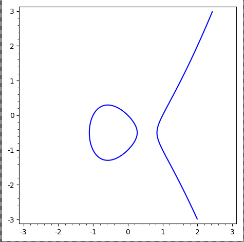

- $x^n+y^n-1$: does it even contain a ${\mathbb{Q}}{\hbox{-}}$point? (Fermat’s Last Theorem)
- $x^2 + 1$, which has no ${\mathbb{R}}{\hbox{-}}$points.
- $x^2 + y^2 + 1/{\mathbb{R}}$ vanishes nowhere, so its ring of functions is not ${\mathbb{R}}[x, y] / \left\langle{x^2 + y^2 + 1}\right\rangle$ (problem: ${\mathbb{R}}$ is not algebraically closed)
- $x^2 - y^2 = 0$ over ${\mathbb{C}}$ is not a manifold (no chart at the origin):

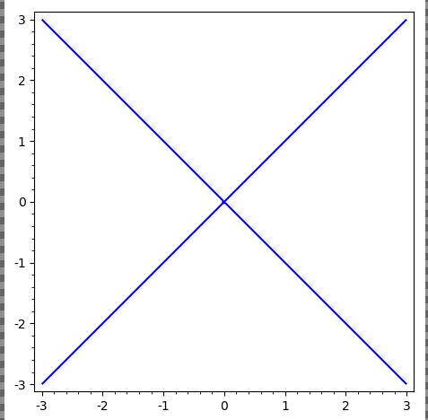

- $x+y+1/{\mathbb{F}}_3$, which has 3 points over ${\mathbb{F}}_3^2$, but $f(x, y) = (x^3 - x)(y^3-y)$ vanishes at every point
  - Not possible when algebraically closed (is there nonzero polynomial that vanishes on every point in ${\mathbb{C}}$?)
  - $V(f) = {\mathbb{F}}_3^2$, so the coordinate ring is zero instead of ${\mathbb{F}}_3[x, y]/\left\langle{f}\right\rangle$ (addressed by scheme theory)

If $f \in {\mathbb{R}}[x, y]$ is of degree $d$, then
$$\begin{align*} \pi_1 V(f) \subseteq {\mathbb{R}}^2 \leq 1 + {(d-1)(d-2) \over 2} \end{align*}$$

> Actual statement: the number of connected components is bounded above by this quantity.

Take the curve
$$\begin{align*} X = \left\{{(x, y, z) = (t^3, t^4, t^5) \in {\mathbb{C}}^3 {~\mathrel{\Big|}~}t\in {\mathbb{C}}}\right\} .\end{align*}$$

Compare to linear algebra: codimension $d$ iff cut out by exactly $d$ equations.

Given the Riemann surface
$$\begin{align*} y^2 = (x-1)(x-2)\cdots(x-2n) ,\end{align*}$$
how to visualize the solution set?

Fact: on ${\mathbb{C}}$ with some slits, you can consistently choose a square root of the RHS.

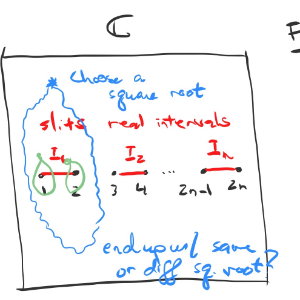

Away from $x=1, \cdots, 2n$, there are two solutions for $y$ given $x$.

After gluing along strips, obtain:

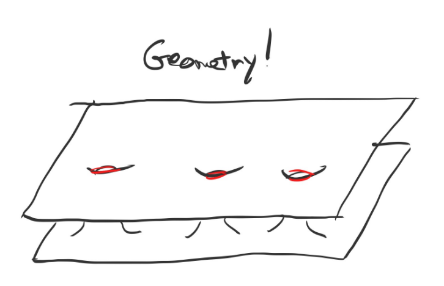

# Tuesday, August 25

Let $k = \mkern 1.5mu\overline{\mkern-1.5muk\mkern-1.5mu}\mkern 1.5mu$ and $R$ a ring containing ideals $I, J$.

Recall that the *radical* of $I$ is defined as
$$\begin{align*} \sqrt{I} = \left\{{r\in R ~{\text{s.t.}}~r^k\in I \text{ for some } k\in {\mathbb{N}}}\right\} .\end{align*}$$

Let $I = (x_1, x_2^2) \subset {\mathbb{C}}[x_1, x_2]$, so $I = \left\{{ f_1 x_1 + f_2 x_2 ~{\text{s.t.}}~f_1, f_2 \in {\mathbb{C}}[x_1, x_2]}\right\}$. Then $\sqrt{I} = (x_1, x_2)$, since $x_2^2 \in I \implies x_2 \in \sqrt{I}$.

Given $f\in k[x_1, \cdots, x_n]$, take its value at $a = (a_1, \cdots, a_n)$ and denote it $f(a)$. Set $\deg(f)$ to be the largest value of $i_1 + \cdots + i_n$ such that the coefficient of $\prod x_j ^{i_j}$ is nonzero.

$\deg(x_1 + x_2^2 + x_1 x_2^3 = 4)$

1. Affine $n{\hbox{-}}$space ${\mathbb{A}}^n = {\mathbb{A}}_k^n$ is defined as $\left\{{(a_1, \cdots, a_n) {~\mathrel{\Big|}~}a_i \in k}\right\}$.

> Remark: not $k^n$, since we won’t necessarily use the vector space structure (e.g. adding points).
2. Let $S\subset k[x_1, \cdots, x_n]$ to be a set of polynomials. Then define $V(S) = \left\{{x\in {\mathbb{A}}^n ~{\text{s.t.}}~f(x) = 0}\right\} \subset {\mathbb{A}}^n$ to be an *affine variety*.
- ${\mathbb{A}}^n = V(0)$.
- For any point $(a_1, \cdots, a_n)\in {\mathbb{A}}^n$, then $V(x_1 - a_1, \cdots, x_n - a_n) = \left\{{a_1, \cdots, a_n}\right\}$ uniquely determines the point.
- For any finite set $r_1, \cdots, r_k \in {\mathbb{A}}^1$, there exists a polynomial $f(x)$ whose roots are $r_i$.

We may as well assume $S$ is an ideal by taking the ideal it generates, $S\subseteq \left\langle{S}\right\rangle = \left\{{\sum g_i f_i {~\mathrel{\Big|}~}g_i \in k[x_1, \cdots, x_n],\, f_i\in S}\right\}$. Then $V(\left\langle{S}\right\rangle) \subset V(S)$.

Conversely, if $f_1, f_2$ vanish at $x\in {\mathbb{A}}^n$, then $f_1 + f_2, gf_1$ also vanish at $x$ for all $g\in k[x_1, \cdots, x_n]$. Thus $V(S) \subset V(\left\langle{S}\right\rangle)$.

- $I+J \mathrel{\vcenter{:}}=\left\{{f+g ~{\text{s.t.}}~f\in I,\, g\in J}\right\}$.
- $IJ \mathrel{\vcenter{:}}=\left\{{\sum_{i=1}^N f_i g_i ~{\text{s.t.}}~f_i\in I,\, g_i\in J, N\in {\mathbb{N}}}\right\}$.
- If $I+J = \left\langle{1}\right\rangle$ then $I\cap J = IJ$ (coprime or comaximal)

Note that if $I = \left\langle{a}\right\rangle$ and $J = \left\langle{b}\right\rangle$, then $I + J = \left\langle{a}\right\rangle + \left\langle{b}\right\rangle = \left\langle{a, b}\right\rangle$.

1. If $S_1 \subseteq S_2$ then $V(S_1) \supseteq V(S_2)$.
2. $V(S_1) \cup V(S_2) = V(S_1 S_2) = V(S_1 \cap S_2)$.
3. $\bigcap V(S_i) = V\qty{\bigcup S_i}$.

We thus have a map
$$\begin{align*} V: \left\{{\text{Ideals in } k[x_1, \cdots, x_n]}\right\} \to \left\{{\text{Affine varieties in } {\mathbb{A}}^n}\right\} .\end{align*}$$

Let $X\subset {\mathbb{A}}^n$ be any set, then *the ideal of $X$* is defined as
$$\begin{align*} I(X) \mathrel{\vcenter{:}}=\left\{{f\in k[x_1, \cdots, x_n] ~{\text{s.t.}}~f(x) = 0\, \forall x\in X}\right\} .\end{align*}$$

Let $X$ be the union of the $x_1$ and $x_2$ axes in ${\mathbb{A}}^2$, then $I(X) = (x_1 x_2) = \left\{{x_1 x_2 g~{\text{s.t.}}~g\in k[x_1, x_2]}\right\}$.

$I(X)$ is a radical ideal, i.e. $I(X) = \sqrt{I(X)}$.

This is because $f(x)^k = 0 \forall x\in X$ implies $f(x) = 0$ for all $x\in X$, so $f^k \in I(X)$ and thus $f\in I(X)$.

Our correspondence is thus
$$\begin{align*} \left\{{\substack{\text{Ideals in } k[x_1, \cdots, x_n]}}\right\} &\xrightarrow{V} \left\{{\substack{\text{Affine Varieties}}}\right\} \\ \left\{{\substack{\text{Radical Ideals}}}\right\} &\xleftarrow{I} \left\{{\substack{\text{?}}}\right\} .\end{align*}$$

1. For any affine variety $X$, $V(I(X)) = X$.
2. For any ideal $J \subset k[x_1, \cdots, x_n]$, $I(V(J)) = \sqrt{J}$.

Thus there is a bijection between radical ideals and affine varieties.

## Proof of Nullstellensatz

Recall the Hilbert Basis Theorem: any ideal in a finitely generated polynomial ring over a field is again finitely generated.

We need to show 4 inclusions, 3 of which are easy.

a: $X \subset V(I(X))$:

- If $x\in X$ then $f(x) = 0$ for all $f\in I(X)$.
- So $x\in V(I(X))$, since every $f\in I(X)$ vanishes at $x$.

b: $\sqrt{J} \subset I(V(J))$:

- If $f\in \sqrt{J}$ then $f^k \in J$ for some $k$.
- Then $f^k(x) = 0$ for all $x\in V(J)$.
- So $f(x) = 0$ for all $x\in V(J)$.
- Thus $f\in I(V(J))$.

c: $V(I(X)) \subset X$:

- Need to now use that $X$ is an affine variety.
  - Counterexample: $X = {\mathbb{Z}}^2 \subset {\mathbb{C}}^2$, then $I(X) = 0$. But $V(I(X)) = {\mathbb{C}}^2$, but ${\mathbb{C}}^2 \not\subset {\mathbb{Z}}^2$.
- By (b), $I(V(J)) \supset \sqrt{J} \supset J$.
- Since $V({\,\cdot\,})$ is order-reversing, taking $V$ of both sides reverses the containment.
- So $V(I(V(J))) \subset V(J)$, i.e. $V(I(X)) \subset X$.

d: $I(V(J)) \subset \sqrt{J}$ (hard direction)

Suppose $k$ is algebraically closed and uncountable (still true in countable case by a different proof).

Then the maximal ideals in $k[x_1, \cdots, x_n]$ are of the form $(x_1 - a_1, \cdots, x_n - a_n)$.

Let ${\mathfrak{m}}$ be a maximal ideal, then by the Hilbert Basis Theorem, ${\mathfrak{m}}= \left\langle{f_1, \cdots, f_r}\right\rangle$ is finitely generated.

Let $L = {\mathbb{Q}}[\left\{{c_i}\right\}]$ where the $c_i$ are all of the coefficients of the $f_i$ if $\operatorname{ch}(K) = 0$, **or** ${\mathbb{F}}_p[\left\{{c_i}\right\}]$ if $\operatorname{ch}(k) = p$. Then $L\subset k$.

Define ${\mathfrak{m}}_0 = {\mathfrak{m}}\cap L[x_1, \cdots, x_n]$. Note that by construction, $f_i \in {\mathfrak{m}}_0$ for all $i$, and we can write ${\mathfrak{m}}= {\mathfrak{m}}_0 \cdot k[x_1, \cdots, x_n]$.

**Claim**: ${\mathfrak{m}}_0$ is a maximal ideal.

If it were the case that
$$\begin{align*} {\mathfrak{m}}_0 \subsetneq {\mathfrak{m}}_0' \subsetneq L[x_1, \cdots, x_n] ,\end{align*}$$
then
$$\begin{align*} {\mathfrak{m}}_0\cdot k[x_1, \cdots, x_n] \subsetneq {\mathfrak{m}}_0'\cdot k[x_1, \cdots, x_n] \subsetneq k[x_1, \cdots, x_n] .\end{align*}$$

> So far: constructed a smaller polynomial ring and a maximal ideal in it.

Thus $L[x_1, \cdots, x_n]/{\mathfrak{m}}_0$ is a field that is finitely generated over either ${\mathbb{Q}}$ or ${\mathbb{F}}_p$.

Any finitely-generated field extension $k_1 \hookrightarrow k_2$ is a finite extension of a purely transcendental extension, i.e. there exist $t_1, \cdots, t_\ell$ such that $k_2$ is finite over $k_1(t_1, \cdots, t_\ell)$.

> Note: this theorem is perhaps more important than the Nullstellensatz!

Thus $L[x_1, \cdots, x_n]/{\mathfrak{m}}_0$ is finite over some ${\mathbb{Q}}(t_1, \cdots, t_n)$, and since $k$ is uncountable, there exists an embedding ${\mathbb{Q}}(t_1, \cdots, t_n) \hookrightarrow k$.

> Use the fact that there are only countably many polynomials over a countable field.

This extends to an embedding of $\phi: L[x_1, \cdots, x_n]/{\mathfrak{m}}_0 \hookrightarrow k$ since $k$ is algebraically closed. Letting $a_i$ be the image of $x_i$ under $\phi$, then $f(a_1, \cdots, a_n) = 0$ by construction, $f_i \in (x_i - a_i)$ implies that ${\mathfrak{m}}= (x_i - a_i)$ by maximality.

# Thursday, August 27

Recall Hilbert’s Nullstellensatz:

1. For any affine variety, $V(I(X)) = X$.
2. For any ideal $J{~\trianglelefteq~}k[x_1, \cdots, x_n]$, $I(V(J)) = \sqrt{J}$.

So there’s an order-reversing bijection
$$\begin{align*} \left\{{\substack{\text{Radical ideals } k[x_1, \cdots, x_n]}}\right\} \to{V({\,\cdot\,})}{I({\,\cdot\,})} \left\{{\substack{\text{Affine varieties in } {\mathbb{A}}^n}}\right\} .\end{align*}$$

In proving $I(V(J)) \subseteq \sqrt{J}$, we had an important lemma (Noether Normalization): the maximal ideals of $k[x_1, \cdots, x_n]$ are of the form $\left\langle{x-a_1, \cdots, x-a_n}\right\rangle$.

If $V(I)$ is empty, then $I = \left\langle{1}\right\rangle$.

> Slogan: the only ideals that vanish nowhere are trivial. No common vanishing locus $\implies$ trivial ideal, so there’s a linear combination that equals 1.

By contrapositive, suppose $I\neq \left\langle{1}\right\rangle$. By Zorn’s Lemma, these exists a maximal ideals ${\mathfrak{m}}$ such that $I \subset {\mathfrak{m}}$. By the order-reversing property of $V({\,\cdot\,})$, $V({\mathfrak{m}}) \subseteq V(I)$. By the classification of maximal ideals, ${\mathfrak{m}}= \left\langle{x-a_1, \cdots, x-a_n}\right\rangle$, so $V({\mathfrak{m}}) = \left\{{a_1, \cdots, a_n}\right\}$ is nonempty.

Returning to the proof that $I(V(J)) \subseteq \sqrt{J}$: let $f\in V(I(J))$, we want to show $f\in \sqrt{J}$. Consider the ideal $\tilde J \mathrel{\vcenter{:}}= J + \left\langle{ft - 1}\right\rangle \subseteq k[x_1, \cdots, x_n, t]$.

Observation: $f = 0$ on all of $V(J)$ by the definition of $I(V(J))$. But $ft-1 \neq 0$ if $f=0$, so $V(\tilde J) = V(G) \cap V(ft-1) = \emptyset$.

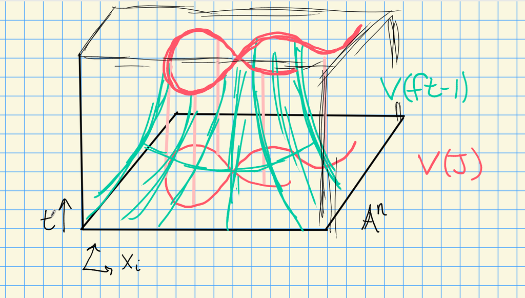

Effect, a hyperbolic tube around $V(J)$, so both can’t vanish

Applying the corollary $\tilde J = (1)$, so $1 = \left\langle{ft-1}\right\rangle g_0(x_1, \cdots, x_n, t) + \sum f_i g_i(x_1, \cdots, x_n, t)$ with $f_i \in J$. Let $t^N$ be the largest power of $t$ in any $g_i$. Thus for some polynomials $G_i$, we have
$$\begin{align*} f^N \mathrel{\vcenter{:}}=(ft-1) G_0(x_1, \cdots, x_n, ft) + \sum f_i G_i(x_1, \cdots, x_n, ft) \end{align*}$$
noting that $f$ does not depend on $t$.

Now take $k[x_1, \cdots, x_n, t]/\left\langle{ft-1}\right\rangle$, so $ft=1$ in this ring. This kills the first term above, yielding
$$\begin{align*} f^N = \sum f_i G_i(x_1, \cdots, x_n, 1) \in k[x_1, \cdots, x_n, t]/\left\langle{ft-1}\right\rangle .\end{align*}$$

Observation: there is an inclusion
$$\begin{align*} k[x_1, \cdots, x_n] \hookrightarrow k[x_1, \cdots, x_n, t]/\left\langle{ft-1}\right\rangle .\end{align*}$$

Why is this true?

Since this is injective, this identity also holds in $k[x_1, \cdots, x_n]$. But $f_i\in J$, so $f\in \sqrt{I}$.

Let $J = \left\langle{x-a_1, \cdots, x-a_n}\right\rangle$, then $I(V(J)) = \sqrt{J} = J$ with $J$ maximal. Thus there is a correspondence
$$\begin{align*} \left\{{\substack{\text{Points of } {\mathbb{A}}^n}}\right\} \iff \left\{{\substack{\text{Maximal ideals of }k[x_1, \cdots, x_n]}}\right\} .\end{align*}$$

1. $I(X_1 \cup X_2) = I(X_1) \cap I(X_2)$.
2. $I(X_1) \cap I(X_2) = \sqrt{I(X_1) + I(X_2)}$.

We proved (a) on the variety side.

For (b), by the Nullstellensatz, $X_i = V(I(X_i))$, so
$$\begin{align*} I(X_1\cap X_2) &= I\qty{ VI(X_1) \cap VI(X_2)} \\ &= IV\qty{I(X_1) + I(X_2)} \\ &= \sqrt{I(X_1) + I(X_2)} .\end{align*}$$

Example of property (b):

Take $X_1 = V(y-x^2)$ and $X_2 = V(y)$, a parabola and the $x{\hbox{-}}$axis.

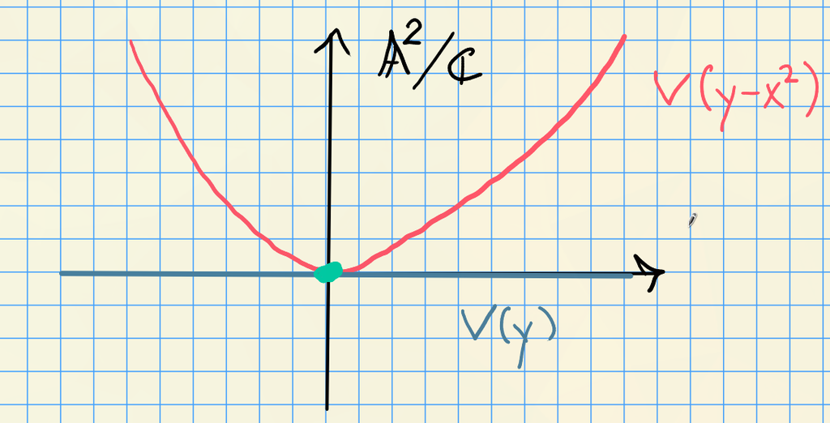

Image

Then $X_1 \cap X_2 = \left\{{(0, 0)}\right\}$, and $I(X_1) + I(X_2) = \left\langle{y-x^2, y}\right\rangle = \left\langle{x^2, y}\right\rangle$, but $I(X_1 \cap X_2) = \left\langle{x, y}\right\rangle = \sqrt{\left\langle{x^2, y}\right\rangle}$.

If $f, g\in k[x_1, \cdots, x_n]$, and suppose $f(x) = g(x)$ for all $x\in {\mathbb{A}}^n$. Then $f = g$.

Since $f-g$ vanishes everywhere, $f-g \in I({\mathbb{A}}^n) = I(V(0)) = \sqrt{0} = 0$.

More generally suppose $f(x) = g(x)$ for all $x\in X$, where $X$ is some affine variety. Then by definition, $f-g \in I(X)$, so a “natural” space of functions on $X$ is $k[x_1,\cdots, x_n]/I(X)$.

For an affine variety $X$, the *coordinate ring of $X$* is
$$\begin{align*} A(X) \mathrel{\vcenter{:}}= k[x_1, \cdots, x_n]/ I(X) .\end{align*}$$

Elements $f\in A(X)$ are called *polynomial* or *regular* functions on $X$.

Observation: The constructions $V({\,\cdot\,}), I({\,\cdot\,})$ work just as well for $A(X)$ and $X$.

Given any $S\subset A(Y)$ for $Y$ an affine variety,
$$\begin{align*} V(S) = V_Y(S) \mathrel{\vcenter{:}}=\left\{{x\in Y ~{\text{s.t.}}~f(x) = 0\,\,\forall f\in S}\right\} .\end{align*}$$

Given $X\subset Y$ a subset,
$$\begin{align*} I(X) = I_Y(X) \mathrel{\vcenter{:}}=\left\{{f\in A(Y) ~{\text{s.t.}}~f(x) = 0\,\,\forall x\in X}\right\} \subseteq A(Y) .\end{align*}$$

For $X\subset Y \subset {\mathbb{A}}^n$, we have $I(X) \supset I(Y) \supset I({\mathbb{A}}^n)$, so we have maps

[figure not shown]

Let $X\subset Y$ be an affine subvariety, then

1. $A(X) = A(Y) / I_Y(X)$
2. There is a correspondence
   $$\begin{align*} \left\{{\substack{\text{Affine subvarieties of }Y}}\right\} &\iff \left\{{\substack{\text{Radical ideals in }A(Y)}}\right\} \\ X &\mapsto I_Y(X) \\ V_Y(J) &\mapsfrom J .\end{align*}$$

Properties are inherited from the case of ${\mathbb{A}}^n$, see exercise in Gathmann.

Let $Y = V(y-x^2) \subset {\mathbb{A}}^2/{\mathbb{C}}$ and $X = \left\{{(1, 1)}\right\} = V(x-1, y-1)\subset {\mathbb{A}}^2/{\mathbb{C}}$.

Then there is an inclusion $\left\langle{y-x^2}\right\rangle \subset \left\langle{x-1, y-1}\right\rangle$ (e.g. by Taylor expanding about the point $(1, 1)$), and there is a map

[figure not shown]

# Tuesday, September 01

Last time: $V(I) = \left\{{x\in {\mathbb{A}}^n ~{\text{s.t.}}~f(x) = 0 \, \forall x\in I}\right\}$ and $I(X) = \left\{{f\in k[x_1, \cdots, x_n] ~{\text{s.t.}}~f(x) = 0\, \forall x\in X}\right\}$. We proved the Hilbert Nullstellensatz $I(V(J)) = \sqrt{J}$, defined the coordinate ring of an affine variety $X$ as $A(X) \mathrel{\vcenter{:}}= k[x_1, \cdots, x_n] / I(X)$, the ring of “regular” (polynomial) functions on $X$.

Recall that a *topology* on $X$ can be defined as a collection of “closed” subsets of $X$ that are closed under arbitrary intersections and finite unions. A subset $Y\subset X$ inherits a subspace topology with closed sets of the form $Z\cap Y$ for $Z\subset X$ closed.

Let $X$ be an affine variety. The closed sets are affine subvarieties $Y\subset X$.

We have $\emptyset, X$ closed, since

1. $V_X(1) = \emptyset$,
2. $V_X(0) = X$

Closure under finite unions: Let $V_X(I), V_X(J)$ be closed in $X$ with $I, J \subset A(X)$ ideals. Then $V_X(IJ) = V_X(I) \cup V_X(J)$.

Closure under intersections: We have $\bigcap_{i\in \sigma} V_X(J) = V_X\qty{ \sum_{i\in \sigma} J_i}$.

There are few closed sets, so this is a “weak” topology.

Compare the classical topology on ${\mathbb{A}}^1/{\mathbb{C}}$ to the Zariski topology.

Consider the set $A\mathrel{\vcenter{:}}=\left\{{x\in {\mathbb{A}}^1/{\mathbb{C}}~{\text{s.t.}}~{\left\lVert {x} \right\rVert} \leq 1}\right\}$, which is closed in the classical topology.

But $A$ is not closed in the Zariski topology, since the closed subsets are finite sets or the whole space.

> Here the topology is in fact the cofinite topology.

Let $f: {\mathbb{A}}^1/k\to {\mathbb{A}}^1/k$ be any injective map. Then $f$ is necessarily continuous wrt the Zariski topology.

Thus the notion of continuity is too weak in this situation.

Consider $X\times Y$ a product of affine varieties. Then there is a product topology where open sets are of the form $\bigcup_{i=1}^n U_i \times V_i$ with $U_i, V_i$ open in $X, Y$ respectively.

This is the wrong topology! On ${\mathbb{A}}^1 \times{\mathbb{A}}^1 = {\mathbb{A}}^2$, the diagonal $\Delta \mathrel{\vcenter{:}}= V(x-y)$ is closed in the Zariski topology on ${\mathbb{A}}^2$ but not in the product topology.

Consider ${\mathbb{A}}^2/{\mathbb{C}}$, so the closed sets are curves and points. Observation: $V(x_1 x_2 ) \subset {\mathbb{A}}^2/{\mathbb{C}}$ decomposed into the union of the coordinate axes $X_1 \mathrel{\vcenter{:}}= V(x_1)$ and $X_2 \mathrel{\vcenter{:}}= V(x_2)$. The Zariski topology can detect these decompositions.

Let $X$ be a topological space.

1. $X$ is *reducible* iff there exist nonempty proper closed subsets $X_1 ,X_2 \subset X$ such that $X = X_1 \cup X_2$. Otherwise, $X$ is said to be *irreducible*.
2. $X$ is *disconnected* if there exist $X_1, X_2 \subset X$ such that $X = X_1 {\coprod}X_2$. Otherwise, $X$ is said to be *connected*.

$V(x_1 x_2)$ is reducible but connected.

Let $X$ be a disconnected affine variety with $X = X_1 {\coprod}X_2$. Then $A(X) \cong A(X_1) \times A(X_2)$.

We have $X_1 \cup X_2 = X$, so $I(X_1) \cap I(X_2) = I(X) = (0)$ in the coordinate ring $A(X)$ (recalling that it is a quotient by $I(X)$.)

Since $X_1 \cap X_1 \emptyset$, we have
$$\begin{align*} I(X_1 \cap X_2) = \sqrt{I(X_1) + I(X_2) } = I(\emptyset) = \left\langle{1}\right\rangle .\end{align*}$$

Thus $I(X_1) + I(X_2) = \left\langle{1}\right\rangle$, and by the Chinese Remainder Theorem, the following map is an isomorphism:
$$\begin{align*} A(X) \to A(X)/I(X_1) \times A(X) / I(X_2) .\end{align*}$$

But the codomain is precisely $A(X_1) \times A(X_2)$.

An affine variety $X$ is irreducible $\iff$ $A(X)$ is an integral domain.

$\implies$: By contrapositive, suppose $f_1, f_2 \in A(X)$ are nonzero with $f_1 f_2 = 0$. Let $X_i = V(f_i)$, then $X= V(0) = V(f_1 f_2) = X_1 \cup X_2$ which are closed and proper since $f_i \neq 0$.

$\impliedby$: Suppose $X$ is reducible with $X = X_1 \cup X_2$ with $X_i$ proper and closed. Define $J_i \mathrel{\vcenter{:}}= I(X_i)$, and note $J_i \neq 0$ because $V(J_i) = V(I(X_i)) = X_i$ by part (a) of the Nullstellensatz.

So there exists a nonzero $f_i \in J_i = I(X_i)$, so $f_i$ vanishes on $X_i$. But then $V(f_1) \cup V(f_2) \supset X_1 \cup X_2 = X$, so $X= V(f_1 f_2)$ and $f_1 f_2 \in I(X) = \left\langle{0}\right\rangle$ and $f_1 f_2 = 0$. So $A(X)$ is not a domain.

Let $X = \left\{{p_1, \cdots, p_d}\right\}$ be a finite set in ${\mathbb{A}}^n$. The Zariski topology on $X$ is the discrete topology, and $X = {\coprod}\left\{{p_i}\right\}$. So
$$\begin{align*} A(X) = A({\coprod}\left\{{p_i}\right\}) = \prod_{i=1}^d A({\left\{{p_i}\right\}}) = \prod_{i=1}^d k[x_1, \cdots, x_n] / \left\langle{x_j - a_j(p_i)}\right\rangle_{j=1}^d .\end{align*}$$

Set $V(x_1 x_2) = X$, then $A(X) = k[x_1, x_2]/ \left\langle{x_1 x_2}\right\rangle$. This not being a domain (since $x_1 x_2 = 0$) corresponds to $X = V(x_1) \cup V(x_2)$ not being irreducible.

${\mathbb{A}}^2/k$ is irreducible since $k[x_1, \cdots x_n]$ is a domain.

Then the coordinate ring is given by $A(X) = {\mathbb{C}}[x, y, z] / \left\langle{xz, z^2 - z}\right\rangle = {\mathbb{C}}[x, y, z] / \left\langle{z}\right\rangle \oplus {\mathbb{C}}[x, y,z] / \left\langle{x, z-1}\right\rangle$.

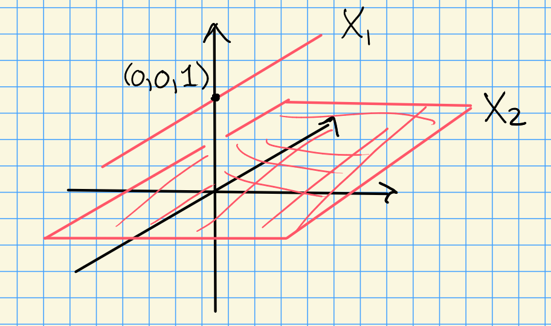

Image

# Thursday, September 03

Recall that the Zariski topology is defined on an affine variety $X = V(J)$ with $J {~\trianglelefteq~}k[x_1, \cdots, x_n]$ by describing the closed sets.

$X$ is irreducible if its coordinate ring $A(X)$ is a domain.

There is a 1-to-1 correspondence
$$\begin{align*} \left\{{\substack{\text{Irreducible subvarieties} \\ \text{of }X}}\right\} \iff \left\{{\substack{\text{Prime ideals} \\ \text{in }A(X)}}\right\} .\end{align*}$$

Suppose $Y\subset X$ is an affine subvariety. Then
$$\begin{align*} A(X) / I_X(Y) = A(Y) .\end{align*}$$

By NSS, there is a bijection between subvarieties of $X$ and radical ideals of $A(X)$ where $Y\mapsto I_X(Y)$. A quotient is a domain iff quotienting by a prime ideal, so $A(Y)$ is a domain iff $I_X(Y)$ is prime.

Recall that ${\mathfrak{p}}{~\trianglelefteq~}R$ is prime when $fg\in {\mathfrak{p}}\iff f\in {\mathfrak{p}}$ or $g\in {\mathfrak{p}}$. Thus $\mkern 1.5mu\overline{\mkern-1.5muf\mkern-1.5mu}\mkern 1.5mu \mkern 1.5mu\overline{\mkern-1.5mug\mkern-1.5mu}\mkern 1.5mu = 0$ in $R/{\mathfrak{p}}$ implies $\mkern 1.5mu\overline{\mkern-1.5muf\mkern-1.5mu}\mkern 1.5mu = 0$ or $\mkern 1.5mu\overline{\mkern-1.5mug\mkern-1.5mu}\mkern 1.5mu = 0$ in $R/{\mathfrak{p}}$, i.e. $R/{\mathfrak{p}}$ is a domain.

Finally note that prime ideals are radical (easy proof).

Consider ${\mathbb{A}}^2/{\mathbb{C}}$ and some subvarieties $C_i$:

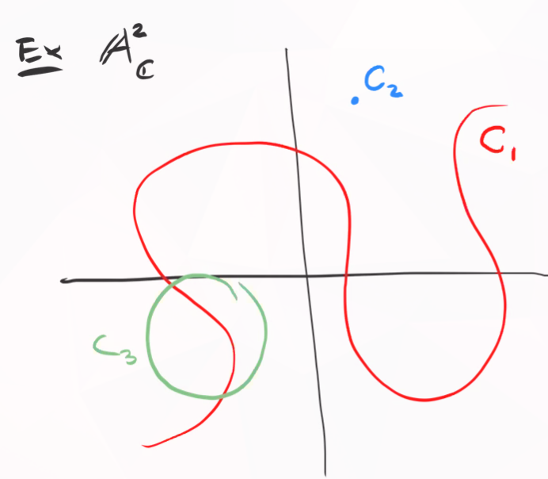

Subvarieties

Then irreducible subvarieties correspond to prime ideals in ${\mathbb{C}}[x, y]$. Here $C_1, C_3$ correspond to $V(f), V(g)$ for $f,g$ irreducible polynomials, whereas $C_2$ corresponds to a maximal ideal, i.e. $V(x_1 - a_1, x_2 - a_2)$.

Note that $I(C_1 \cup C_2 \cup C_3)$ is not a prime ideal, since the variety is reducible as the union of 3 closed subsets.

A finite set is irreducible iff it contains only one point.

Any irreducible topological space is connected, since irreducible requires a union but connectedness requires a *disjoint* union.

${\mathbb{A}}^n/k$ is irreducible: by prop 2.8, its irreducible iff the coordinate ring is a domain. However $A({\mathbb{A}}^n) = k[x_1, \cdots, x_n]$, which is a domain.

$V(x_1 x_2)$ is not irreducible, since it’s equal to $V(x_1) \cup V(x_2)$.

A *Noetherian* topological space $X$ is a space with no infinite strictly decreasing sequence of closed subsets.

An affine variety $X$ with the zariski topology is a noetherian space.

Let $X_0 \supsetneq X_1 \supsetneq \cdots$ be a decreasing sequence of closed subspaces. Then $I(X_0) \subsetneq I(X_1) \subsetneq$. Note that these containments are strict, otherwise we could use $V(I(X_1)) = X_1$ to get an equality in the original chain.

Recall that a ring $R$ is Noetherian iff every ascending chain of ideals terminates. Thus it suffices to show that $A(X)$ is Noetherian.

We have $A(X) = k[x_1, \cdots, x_{n}] / I(X)$, and if this had an infinite chain $I_1 \subsetneq I_2 \subsetneq \cdots$ lifts to a chain in $k[x_1, \cdots, x_{n}]$, which is Noetherian. A useful fact: $R$ noetherian implies that $R[x]$ is noetherian, and fields are always noetherian.

Any subspace $A\subset X$ of a noetherian space is noetherian. To see why, suppose we have a chain of closed sets in the subspace topology,
$$\begin{align*} A\cap X_0 \supsetneq A\cap X_1 \supsetneq \cdots .\end{align*}$$

Then $X_0 \supsetneq X_1 \supsetneq \cdots$ is a strictly decreasing chain of closed sets in $X$. Why strictly decreasing: $\cap^n X_i = \cap^{n+1} X_i \implies A\cap^n X_i = A\cap^{n+1} X_i$, a contradiction.

Every noetherian space $X$ is a finite union of irreducible closed subsets, i.e. $X = \bigcup_{i=1}^k X_i$. If we further assume $X_i \not\subset X_j$ for all $i, j$, then the $X_i$ are unique up to permutation.

The $X_i$ are the **components** of $X$. In the previous example $C_1 \cup C_2 \cup C_3$ has three components.

If $X$ is irreducible, then $X=X$ and this holds.

Otherwise, write $X = X_1 \cup X_2$ with $X_i$ proper closed subsets. If $X_1$ and $X_1'$ are irreducible, we’re done, so otherwise suppose wlog $X_1'$ is not irreducible.

Then we can express $X = X_1 \cup\qty{X_2 \cup X_2'}$ with $X_2, X_2' \subset X_1'$ closed and proper.

Thus we can obtain a tree whose leaves are proper closed subsets:

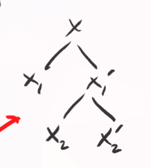

Image

This tree terminates because $X$ is Noetherian: if it did not, this would generate an infinite decreasing chain of subspaces.

We now want to show that the decomposition is unique if no two components are contained in the other.

Suppose
$$\begin{align*} X= \bigcup_{i=1}^k X_i = \bigcup_{j=1}^\ell X_j' .\end{align*}$$

Note that $X_i \subset X$ implies that $X_i = \bigcup_{j=1}^\ell X_i \cap X_j'$. But $X_i$ is irreducible and this would express $X_i$ as a union of proper closed subsets, so some $X_i \cap X_j'$ is *not* a proper closed subset.

Thus $X_i = X_i \cap X_j'$ for some $j$, which forces $X_i \subset X_j'$. Applying the same argument to $X_j'$ to obtain $X_j' \subset X_k$ for some $k$.

Then $X_i \subset X_j' \subset X_k$, but $X_ i \not\subset X_j$ when $j\neq i$. Thus $X_i = X_j' = X_k$, forcing the $X_i$ to be unique up to permutation.

Recall from ring theory: for $I\subset R$ and $R$ noetherian, $I$ has a *primary decomposition* $I = \bigcap_{i=1}^k Q_i$ with $\sqrt{Q_i}$ prime. Assuming the $Q_i$ are minimal in the sense that $\sqrt{Q_i} \not\subset \sqrt{Q_j}$ for any $i, j$, this decomposition is unique.

Applying this to $I(X) {~\trianglelefteq~}k[x_1, \cdots, x_{n}] = R$ yields
$$\begin{align*} I(X) = \bigcap_{i=1}^k Q_i \implies X = V(I(X)) = \bigcup_{i=1}^k V(Q_i) .\end{align*}$$

Letting $P_i = \sqrt{Q_i}$, noting that the $P_i$ are prime and thus radical, we have $V(Q_i) = V(P_i)$. Writing $X = \bigcup V(P_i)$, we have $I(V(P_i)) = P_i$ and thus $A(V(P_i)) = R/P_i$ is a domain, meaning $V(P_i)$ are irreducible affine varieties.

Conversely, if we express $X = \bigcup X_i$, we have $I = I\qty{\bigcup X_i} = \bigcap I(X_i) = \bigcap P_i$ which are irreducible since they are prime.

There is a correspondence
$$\begin{align*} \left\{{\substack{\text{Irreducible components} \\ \text{of } X}}\right\} \iff \left\{{\substack{\text{Minimal prime ideals} \\ \text{in } A(X)}}\right\} ,\end{align*}$$
where here *minimal* is the condition that no pair of ideals satisfies a subset containment.

Let $X$ be an irreducible topological space.

The intersection of nonempty two open sets is *never* empty.

Let $U, U'$ be open and $X\setminus U, X\setminus U'$ closed. Then $U\cap U' = \emptyset \iff (X\setminus U) \cup(X\setminus U') = X$, but this is not possible since $X$ is irreducible.

> Irreducible iff any two nonempty open sets intersect.

Any nonempty open set is dense, i.e. if $U\subset X$ is open then its closure $\operatorname{cl}_X(U)$ is dense in $X$.

Write $X = \operatorname{cl}_X(U) \cup(X\setminus U)$. Since $X\setminus U \neq X$ and $X$ is irreducible, we have $\operatorname{cl}_X(U) = X$.

# Tuesday, September 08

Review: we discussed irreducible components. Recall that the *Zariski topology* on an affine variety $X$ has affine subvarieties as closed sets, and a *noetherian space* has no infinitely decreasing chains of closed subspaces.

We showed that any noetherian space has a decomposition into irreducible components $X = \cup X_i$ with $X_i$ closed, irreducible, and unique such that no two are subsets of each other. Applying this to affine varieties, a descending chain of subspaces $X_0 \supsetneq X_1 \cdots$ in $X$ corresponds to an increasing chain of ideals $I(X_0) \subsetneq I(X_1) \cdots$ in $A(X)$. Since $k[x_1, \cdots, x_{n}]$ is a noetherian ring, this chain terminates, so affine varieties are noetherian.

## Dimension

Let $X$ be a topological space.

1. The *dimension* $\dim X \in {\mathbb{N}}\cup\left\{{\infty}\right\}$ is either $\infty$ or the length $n$ of the longest chain of **irreducible** closed subsets $\emptyset \neq Y_0 \subsetneq \cdots \subsetneq Y_n \subset X$ where $Y_n$ need not be equal to $X$.
2. The *codimension* of $Y$ in $X$, $\operatorname{codim}_X(Y)$, for an irreducible subset $Y\subseteq X$ is the length of the longest chain $Y\subset Y_0 \subsetneq Y_1 \cdots \subset X$.

Consider ${\mathbb{A}}^1/k$, what are the closed subsets? The finite sets, the empty set, and the entire space.

What are the irreducible closed subsets? Every point is a closed subset, so sets with more than one point are reducible. So the only irreducible closed subsets are $\left\{{a}\right\}, {\mathbb{A}}^1/k$, since an affine variety is irreducible iff its coordinate ring is a domain and $A({\mathbb{A}}^1/k) = k[x]$. We can check
$$\begin{align*} \emptyset \subseteq Y_0 = \left\{{a}\right\} \subseteq Y_1 = {\mathbb{A}}^1/k ,\end{align*}$$

which is of length $1$, so $\dim({\mathbb{A}}^1/k) = 1$.

> Note that we count the number of nontrivial strict subset containments in this chain.

Consider $V(x_1 x_2) \subset {\mathbb{A}}^2/k$, the union of the $x_i$ axes. Then the closed subsets are $V(x_1), V(x_2)$, along with finite sets and their unions. What is the longest chain of irreducible closed subsets?

Note that $k[x_1, x_2] / \left\langle{x_1}\right\rangle \cong k[x_2]$ is a domain, so $V(x_i)$ are irreducible. So we can have a chain
$$\begin{align*} \emptyset \subsetneq \left\{{a}\right\} \subsetneq V(x_1) \subset X ,\end{align*}$$
where $a$ is any point on the $x_2{\hbox{-}}$axis, so $\dim(X) = 1$.

The only closed sets containing $V(x_1)$ are $V(x_1)\cup S$ for $S$ some finite set, which can not be irreducible.

You may be tempted to think that if $X$ is noetherian then the dimension is finite. However, finite dimension requires a bounded length on descending/ascending chains, whereas noetherian only requires “termination”, which may not happen in a bounded number of steps. So this is **false**!

Take $X = {\mathbb{N}}$ and define a topology by setting closed subsets be the sets $\left\{{0, \cdots, n}\right\}$ as $n$ ranges over ${\mathbb{N}}$, along with ${\mathbb{N}}$ itself. Is $X$ noetherian? Check descending chains of closed sets:

$$\begin{align*} {\mathbb{N}}\supsetneq \left\{{0, \cdots, N}\right\} \supsetneq \left\{{0, \cdots, N-1}\right\} \cdots ,\end{align*}$$

which has length at most $N$, so it terminates and $X$ is noetherian.

But note that all of these closed subsets $X_N \mathrel{\vcenter{:}}=\left\{{0, \cdots, N}\right\}$ are irreducible. Why? If $X_n = X_i \cup X_j$ then one of $i, j$ is equal to $N$, i.e $X_i, X_j = X_N$.

So for every $N$, there exists a chain of irreducible closed subsets of length $N$, implying that $\dim({\mathbb{N}}) = \infty$.

Let $X$ be an affine variety. There is a correspondence
$$\begin{align*} \left\{{\substack{\text{Chains of irreducible closed subsets} \\ Y_0 \subsetneq \cdots \subsetneq Y_n \text{ in } X}}\right\} \left\{{\substack{\text{Chains of prime ideals} \\ P_0\supsetneq \cdots \supsetneq P_n \text{ in } A(X)}}\right\} .\end{align*}$$
Why? We have a correspondence between closed subsets and radical ideals. If we specialize to irreducible, we saw that these correspond to radical ideals $I\subset A(X)$ such that $A(Y) \mathrel{\vcenter{:}}= A(X) / I$ is a domain, which precisely correspond to prime ideal in $A(X)$.

We thus make the following definition:

The *krull dimension* of a ring $R$ is the length $n$ of the longest chain of prime ideals
$$\begin{align*} P_0 \supsetneq P_1 \supsetneq \cdots \supsetneq P_n .\end{align*}$$

This uses the key fact from commutative algebra: a finitely generated $k{\hbox{-}}$algebra $M$ satisfies

1. $M$ has finite $k{\hbox{-}}$dimension
2. If $M$ is a domain, every maximal chain has the same length.

From scheme theory: for any ring $R$, there is an associated topological space $\operatorname{Spec}R$ given by the set of prime ideals in $R$, where the closed sets are given by
$$\begin{align*} V(I) = \left\{{\text{Prime ideals } {\mathfrak{p}}{~\trianglelefteq~}R ~{\text{s.t.}}~I\subseteq {\mathfrak{p}}}\right\} .\end{align*}$$

If $R$ is a noetherian ring, then $\operatorname{Spec}(R)$ is a noetherian space.

Using the fact above, let’s compute $\dim {\mathbb{A}}^n/k$. We can take the following chain of prime ideals in $k[x_1, \cdots, x_{n}]$:
$$\begin{align*} 0 \subsetneq \left\langle{x_1}\right\rangle \subsetneq \left\langle{x_1, x_2}\right\rangle \cdots \subsetneq \left\langle{x_1, \cdots, x_n}\right\rangle .\end{align*}$$

By applying $V({\,\cdot\,})$ we obtain
$$\begin{align*} {\mathbb{A}}^n/k \supsetneq {\mathbb{A}}^{n-1}/k \cdots \supsetneq {\mathbb{A}}^0/k = \left\{{0}\right\} \supsetneq \emptyset ,\end{align*}$$
where we know each is irreducible and closed, and it’s easy to check that these are maximal:

If there were an ideal $\left\langle{x_1, x_2}\right\rangle \subset P \subset \left\langle{x_1, x_2, x_3}\right\rangle$, then take $P\cap k[x_1, x_2, x_3] / \left\langle{x_1, x_2}\right\rangle$ which would yield a polynomial ring in $k[x_1]$. But we know the only irreducible sets in ${\mathbb{A}}^1/k$ are a point and the entire space.

So this is a chain of maximal length, implying $\dim {\mathbb{A}}^n/k = n$.

# Thursday, September 10

Recall that the dimension of a ring $R$ is the length of the longest chain of prime ideals. Similarly, for an affine variety $X$, we defined $\dim X$ to be the length of the longest chain of irreducible closed subsets.

These notions of dimension of the same when taking $R = A(X)$, i.e. $\dim {\mathbb{A}}^n/k = n$.

Let $k = \mkern 1.5mu\overline{\mkern-1.5muk\mkern-1.5mu}\mkern 1.5mu$.

1. The dimension of $k[x_1, \cdots, x_n]$ is $n$.
2. All maximal chains of prime ideals have length $n$.

## Proof of Dimension Proposition

The case for $n=0$ is trivial, just take $P_0 = \left\langle{0}\right\rangle$. For $n=1$, easy to see since the only prime ideals in $k[x]$ are $\left\langle{0}\right\rangle$ and $\left\langle{x-a}\right\rangle$, since any polynomial factors into linear factors.

Let $P_0 \subsetneq \cdots \subsetneq P_m$ be a maximal chain of prime ideals in $k[x_1, \cdots, x_{n}]$; we then want to show that $m=n$. Assume $P_0 = \left\langle{0}\right\rangle$, since we can always extend our chain to make this true (using maximality). Then $P_1$ is a minimal prime and $P_m$ is a maximal ideal (and maximals are prime).

$P_1$ is principle, i.e. $P_1 = \left\langle{f}\right\rangle$ for some irreducible $f$.

### Proof That $P_1$ is Principle

$k[x_1, \cdots, x_{n}]$ is a unique factorization domain. This follows since $k$ is a UFD since it’s a field, and $R$ a UFD $\implies R[x]$ is a UFD for any $R$.

> See Gauss’ lemma.

In a UFD, minimal primes are principal. Let $r \in P$, and write $r = u \prod p_i^{n_i}$ with $p_i$ irreducible and $u$ a unit. So some $p_i\in P$, and $p_i$ irreducible implies $\left\langle{p_i}\right\rangle$ is prime. Since $0 \subsetneq \left\langle{p_i}\right\rangle \subset P$, but $P$ was prime and assumed minimal, so $\left\langle{p_i}\right\rangle = P$.

The idea is to now transfer the chain $P_0 \subsetneq \cdots \subsetneq P_m$ to a maximal chain in $k[x_1, \cdots, x_{n-1}]$. The first step is to make a linear change of coordinates so that $f$ is monic in the variable $x_n$.

Take $f=x_1x_2 + x_3^2 x_4$ and map $x_3 \mapsto x_3 + x_4$.

So write
$$\begin{align*} f(x_1, \cdots, x_n) = x_n^d + f_1(x_1, \cdots, x_{n-1}) x_n^{d-1} + \cdots + f_d(x_1, \cdots, x_{n-1}) .\end{align*}$$

We can then descend to $k[x_1, \cdots, x_{n}]$ to $k[x_1, \cdots, x_{n}]/\left\langle{f}\right\rangle$:

[figure not shown]

The first set of downward arrows denote taking the quotient, and the upward is taking inverse images, and this preserves strict inequalities.

An *integral* ring extension $R\hookrightarrow R'$ of $R$ is one such that all $r' \in R'$ satisfying a monic polynomial with coefficients in $R$, where $R'$ is finitely generated.

> In this case, also implies that $R'$ is a finitely-generated $R$ module.

In this case, $k[x_1, \cdots, x_{n-1}] \hookrightarrow k[x_1, \cdots, x_{n}] /\left\langle{f}\right\rangle$ is an integral extension. We want to show that the intersection step above also preserves strictness of inclusions, since it preserves primality.

Suppose $P', Q' \subset R'$ are distinct prime ideals with $R\hookrightarrow R'$ an integral extension. Then if $P'\cap R = Q'\cap R$, neither contains the other, i.e. $P'\not\subset Q'$ and $Q'\not\subset P'$.

Toward a contradiction, suppose $P' \subset Q'$, we then want to show that $Q'\supset P'$. Let $a\in Q'\setminus P'$ (again toward a contradiction), then
$$\begin{align*} R/\qty{P'\cap R} \hookrightarrow R'/P' \end{align*}$$
is integral.

Then $\mkern 1.5mu\overline{\mkern-1.5mua\mkern-1.5mu}\mkern 1.5mu \neq 0$ in $R'/P'$, and there exists a monic polynomial of minimal degree that $\mkern 1.5mu\overline{\mkern-1.5mua\mkern-1.5mu}\mkern 1.5mu$ satisfies, $p(x) = x^n + \sum_{i=2}^n \mkern 1.5mu\overline{\mkern-1.5muc\mkern-1.5mu}\mkern 1.5mu_i x^{n-i}$. This implies $\mkern 1.5mu\overline{\mkern-1.5muc\mkern-1.5mu}\mkern 1.5mu_n \in Q'/P'$ (which will contradict $c_n \in P'$), since if $\mkern 1.5mu\overline{\mkern-1.5muc\mkern-1.5mu}\mkern 1.5mu_n = 0$ then factoring out $x$ yields a lower degree polynomial that $\mkern 1.5mu\overline{\mkern-1.5mua\mkern-1.5mu}\mkern 1.5mu$ satisfies.

But then $\mkern 1.5mu\overline{\mkern-1.5mua\mkern-1.5mu}\mkern 1.5mu_n \in Q'\cap R$, so ???

Question: Given $R\hookrightarrow R'$ is an integral extension, can we lift chains of prime ideals?

In this process, the length of the chain decreased since $\left\langle{0}\right\rangle$ was deleted, but otherwise the chains are in bijective correspondence. So the inductive hypothesis applies. $\hfill\blacksquare$

## Using Dimension Theory

Key fact used: the dimension doesn’t change under integral extensions, i.e. if $R\hookrightarrow R'$ is integral then $\dim R = \dim R'$.

Any affine variety has finite dimension.

We have $\dim X = \dim A(X)$, where $A(X) \mathrel{\vcenter{:}}= k[x_1, \cdots, x_{n}] I$ for some $I(X)=\sqrt{I(X)}$.

The noether normalization lemma (used in proof of nullstellensatz) shows that a finitely generated $k{\hbox{-}}$algebra is an integral extension of some polynomial ring $k[y_1, \cdots, y_d]$. I.e., the following extension is integral:
$$\begin{align*} k[y_1, \cdots, y_d] \hookrightarrow k[x_1, \cdots, x_n]/I .\end{align*}$$

We can conclude that $\dim A(X) = d < \infty$.

Let $X, Y$ be irreducible affine varieties. Then

1. $\dim X\times Y = \dim X + \dim Y$.
2. $Y\subset X \implies \dim X = \dim Y + \operatorname{codim}_X Y$.
3. If $f\in A(X)$ is nonzero, then any component of $V(f)$ has codimension 1.

Why is $X\times Y$ again an affine variety? If $X\subset {\mathbb{A}}^n/k$, $Y\subset {\mathbb{A}}^m/k$ with $X = V(I), Y = V(J)$, then $X\times Y \subset {\mathbb{A}}^n/k \times{\mathbb{A}}^m/k = {\mathbb{A}}^{n+m}/k$ can be given by taking $I+J {~\trianglelefteq~}k[x_1, \cdots, x_n, y_1, \cdots, y_m]$ using the natural inclusions of $k[x_1, \cdots, x_{\ell}]$.

Note that we can write
$$\begin{align*} k[x_1, \cdots, x_n, y_1, \cdots, y_m] = k[x_1, \cdots, x_{n}] \otimes_k k[y_1, \cdots, y_n] \end{align*}$$
where we think of $x_i = x_i \otimes 1, y_j = 1 \otimes y_j$. We thus map $I, J$ to $I\otimes 1 + 1\otimes J$ and obtain $V(I\otimes 1 + 1\otimes J) = X\times Y$ and $A(X\times Y) = A(X)\otimes_k A(Y)$.

In general, for $k{\hbox{-}}$algebras $R,S$,
$$\begin{align*} R/I \otimes_k S/J \cong R\otimes_k S / \left\langle{I\otimes 1 + 1\otimes J}\right\rangle .\end{align*}$$

For $R,S$ finitely generated $k{\hbox{-}}$algebras, $\dim R\otimes_k S = \dim R + \dim S$.

Part (a) is proved by the above remarks.

For part (b), the statement is equivalent to $P\subset A(X)$ with $I(Y) \subset P$ is a member of some maximal chain, along with the statement that all maximal chains are the same length.

# Tuesday, September 15

## Review

Let $k=\mkern 1.5mu\overline{\mkern-1.5muk\mkern-1.5mu}\mkern 1.5mu$, we’re setting up correspondences
$$\begin{align*} \text{Ring Theory} \quad&\quad \text{Geometry/Topology of Affine Varieties} \\ \text{Polynomial functions} \quad&\quad \text{Affine space} \\ k[x_1, \cdots, x_n] \quad&\quad {\mathbb{A}}^n/k \mathrel{\vcenter{:}}=\left\{{{\left[ {a_1, \cdots, a_n} \right]} \in k^n }\right\} \\ \text{Maximal ideals } \left\langle{x_1 - a_1, \cdots, x_n - a_n}\right\rangle \quad&\quad \text{Points } {\left[ {a_1, \cdots, a_n} \right]} \in {\mathbb{A}}^n/k \\ \text{Radical ideals } I{~\trianglelefteq~}k[x_1, \cdots, x_n] \quad&\quad \text{Affine varieties } X\subset {\mathbb{A}}^n/k, \text{ vanishing locii of polynomials} \\ I &\mapsto V(I) \mathrel{\vcenter{:}}=\left\{{a~{\text{s.t.}}~f(a) = 0 \forall f\in I}\right\} \\ I(X) \mathrel{\vcenter{:}}=\left\{{f ~{\text{s.t.}}~{\left.{f}\right|_{X}} = 0}\right\} &\mapsfrom X \\ \text{Radical ideals containing $I(X)$, i.e. ideals in $A(X)$} \quad&\quad \text{closed subsets of $X$, i.e. affine subvarieties} \\ A(X) \text{ is a domain} \quad&\quad \text{$X$ irreducible} \\ \text{$A(X)$ is not a direct sum} \quad&\quad \text{$X$ connected} \\ \text{Prime ideals in }A(X) \quad&\quad \text{Irreducible closed subsets of }X \\ \text{Krull dimension $n$ (longest chain of prime ideals)} \quad&\quad \dim X = n,\, \text{(longest chain of irreducible closed subsets)} .\end{align*}$$

> Recall that we defined the coordinate ring $A(X) \mathrel{\vcenter{:}}= k[x_1, \cdots, x_{n}] / I(X)$, which contained no nilpotents.

We had some results about dimension

1. $\dim X<\infty$ and $\dim {\mathbb{A}}^n = n$.
2. $\dim Y + \operatorname{codim}_X Y = \dim X$ when $Y\subset X$ is irreducible.
3. Only over $\mkern 1.5mu\overline{\mkern-1.5muk\mkern-1.5mu}\mkern 1.5mu = k$, $\operatorname{codim}_X V(f) = 1$.

Take $V(x^2+y^2) \subset {\mathbb{A}}^2/{\mathbb{R}}$

An affine variety $Y$ of

- $\dim Y = 1$ is a **curve**,
- $\dim Y = 2$ is a **surface**,
- $\operatorname{codim}_X Y = 1$ is a **hypersurface in $X$**

Question: Is every hypersurface the vanishing locus of a *single* polynomials $f\in A(X)$?

Answer: This is true iff $A(X)$ is a UFD.

$\operatorname{codim}_R {\mathfrak{p}}$ is the length of the longest chain
$$\begin{align*}P_0 \subsetneq P_1 \subsetneq \cdots \subsetneq P_n = {\mathfrak{p}}.\end{align*}$$

Recall that $f$ is irreducible if $f = f_1 f_2 \implies f_i \in R^{\times}$ for one $i$, and $f$ is prime iff $\left\langle{f}\right\rangle$ is a prime ideal, or equivalently $f{~\Bigm|~}ab \implies f{~\Bigm|~}a$ or $f{~\Bigm|~}b$.

Note that prime implies irreducible, since $f$ divides itself.

Let $R$ be a Noetherian domain, then TFAE

1. All prime ideals of codimension 1 are principal.
2. $R$ is a UFD.

$a\implies b$:

Let $f$ be a nonzero non-unit, we’ll show it admits a prime factorization. If $f$ is not irreducible, then $f = f_1 f_1'$, both non-units. If $f_1'$ is not irreducible, we can repeat this, to get a chain
$$\begin{align*} \left\langle{f}\right\rangle \subsetneq \left\langle{f_1'}\right\rangle \subsetneq \left\langle{f_2'}\right\rangle \subsetneq \cdots ,\end{align*}$$
which must terminate.

This yields a factorization $f = \prod f_i$ with $f_i$ irreducible. To show that $R$ is a UFD, it thus suffices to show that the $f_i$ are prime. Choose a minimal prime ideal containing $f$. We’ll use Krull’s Principal Ideal Theorem: if you have a minimal prime ideal ${\mathfrak{p}}$ containing $f$, its codimension $\operatorname{codim}_R {\mathfrak{p}}$ is one. By assumption, this implies that ${\mathfrak{p}}= \left\langle{g}\right\rangle$ is principal. But $g{~\Bigm|~}f$ with $f$ irreducible, so $f,g$ differ by a unit, forcing ${\mathfrak{p}}= \left\langle{f}\right\rangle$. So $\left\langle{f}\right\rangle$ is a prime ideal.

$b\implies a$:

Let ${\mathfrak{p}}$ be a prime ideal of codimension 1. If ${\mathfrak{p}}= \left\langle{0}\right\rangle$, it is principal, so assume not. Then there exists some nonzero non-unit $f\in {\mathfrak{p}}$, which by assumption has a prime factorization since $R$ is assumed a UFD. So $f=\prod f_i$.

Since ${\mathfrak{p}}$ is a prime ideal and $f\in{\mathfrak{p}}$, some $f_i\in {\mathfrak{p}}$. Then $\left\langle{f_i}\right\rangle \subset {\mathfrak{p}}$ and ${\mathfrak{p}}$ minimal implies $\left\langle{f_i}\right\rangle = {\mathfrak{p}}$, so ${\mathfrak{p}}$ is principal.

Every hypersurface $Y\subset X$ is cut out by a single polynomial, so $Y=V(f)$, iff $A(X)$ is a UFD.

Apply this to $R=A(X)$, we find that there is a bijection
$$\begin{align*} \operatorname{codim}1 \text{ prime ideals} \iff \operatorname{codim}1 \text{ closed irreducible subsets }Y\subset X,\text{ i.e. hypersurfaces} .\end{align*}$$

Taking $A(X) = {\mathbb{C}}[x,y,z]/\left\langle{x^2+y^2-z^2}\right\rangle$, whose real points form a cone:

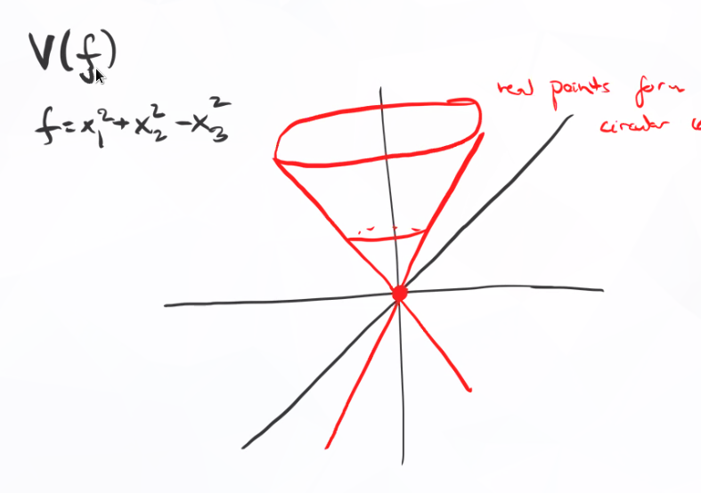

Image

Note that $x^2 + y^2 = (x-iy)(x+iy) = z^2$ in this quotient, so this is not a UFD.

Then taking a line through its surface is a codimension 1 subvariety not cut out by a single polynomial. Such a line might be given by $V(x + iy, z)$, which is 2 polynomials, so why not codimension 2?

Note that $V(z)$ is the union of the lines

- $z = 0, x + iy= 0$,
- $z=0, x - iy = 0$.

Note that it suffices to show that this ring has an irreducible that is not prime. Supposing $z = f_1 f_2$, some $f_i$ is a unit, then $z$ is not prime because $z{~\Bigm|~}xy$ but divides neither of $x,y$.

Note that $k[x_1, \cdots, x_{n}]$ is a UFD since $k$ is a UFD. Applying the corollary, every hypersurface in ${\mathbb{A}}^n$ is cut out by a single irreducible polynomial.

An affine variety $X$ is of **pure dimension $d$** iff every irreducible component $X_i$ is of dimension $d$.

> Note that $X$ is a Noetherian space, so has a unique decomposition $X = \cup X_i$.

Given $X\subset {\mathbb{A}}^n/k$ of pure dimension $n-1$, $X = \cup X_i$ with $X_i$ hypersurfaces with $I(X_j) = \left\langle{f_j}\right\rangle$, $I(X) = \left\langle{f}\right\rangle$ where $f = \prod f_i$.

Given such an $X$, define the **degree of a hypersurface** as the degree of $f$ where $I(X) = \left\langle{f}\right\rangle$.

# Thursday, September 17

## Regular Functions

> See chapter 3 in the notes.

Some examples:

- $X$ a manifold or an open set in ${\mathbb{R}}^n$ has a ring of $C^\infty$ functions.
- $X \subset {\mathbb{C}}$ has a ring of holomorphic functions.
- $X\subset {\mathbb{R}}$ has a ring of real analytic functions

These all share a common feature: it suffices to check if a function is a member on an arbitrary open set about a point, i.e. they are *local*.

Let $X$ be an affine variety and $U\subseteq X$ open. A **regular function** on $U$ is a function $\phi: U\to k$ such that $\phi$ is “locally a fraction”, i.e. a ratio of polynomial functions.

More formally, for all $p\in U$ there exists a $U_p$ with $p\in U_p \subseteq U$ such that $\phi(x) = g(x)/ f(x)$ for all $x\in U_p$ with $f, g\in A(X)$.

For $X$ an affine variety and $f\in A(X)$, consider the open set $U\mathrel{\vcenter{:}}= V(f)^c$. Then ${1\over f}$ is a regular function on $U$, so for $p\in U$ we can take $U_p$ to be all of $U$.

For $X = {\mathbb{A}}^1$, take $f=x-1$. Then ${x\over x-1}$ is a regular function on ${\mathbb{A}}^1 \setminus\left\{{1}\right\}$.

Let $X + V(x_1 x_4 - x_2 x_3)$ and
$$\begin{align*} U \mathrel{\vcenter{:}}= X\setminus V(x_2, x_4) = \left\{{{\left[ {x_1, x_2, x_3, x_4} \right]} ~{\text{s.t.}}~x_1 x_4 = x_2 x_3, x_2\neq 0 \text{ or } x_4\neq 0 }\right\} .\end{align*}$$

Define
$$\begin{align*} \phi: U &\to K \\ {\left[ {x_1, x_2, x_3, x_4} \right]} &\mapsto \begin{cases} {x_1\over x_2} & \text{if } x_2 \neq 0 \\ {x_3\over x_4} & \text{if } x_4 \neq 0 \end{cases} .\end{align*}$$

Notation: we’ll let ${\mathcal{O}}_X(U)$ is the ring of regular function on $U$.

Let $U\subset X$ be an affine variety and $\phi \in {\mathcal{O}}_X(U)$. Then $V(\phi) \mathrel{\vcenter{:}}=\left\{{x\in U ~{\text{s.t.}}~\phi(x) = 0}\right\}$ is closed in the subspace topology on $U$.

For all $a\in U$ there exists $U_a\subset U$ such that $\phi = g_a/f_a$ on $U_a$ with $f_a, g_a \in A(X)$ with $f_a \neq 0$ on $U_a$.

Then
$$\begin{align*} \left\{{x\in U_a ~{\text{s.t.}}~\phi(x) \neq 0}\right\} = U_a \setminus V(g_a)\cap U_a \end{align*}$$
is an open subset of $U_a$, so taking the union over $a$ again yields an open set. But this is precisely $V(\phi)^c$.

Let $U\subset V$ be open in $X$ an *irreducible* affine variety. If $\phi_1, \phi_2 \in {\mathcal{O}}_X(V)$ agree on $U$, then they are equal.

$V(\phi_1 - \phi_2)$ contains $U$ and is closed in $V$. It contains $\mkern 1.5mu\overline{\mkern-1.5muU\mkern-1.5mu}\mkern 1.5mu\cap V$, by an earlier lemma, $X$ irreducible implies that $\mkern 1.5mu\overline{\mkern-1.5muU\mkern-1.5mu}\mkern 1.5mu = X$ and so $V(\phi_1 - \phi_2) =V$.

Compare and contrast: Let $U\subset V \subset {\mathbb{R}}^n$ be open. If $\phi_1, \phi_2 \in C^\infty(V)$ such that $\phi_1, \phi_2$ are equal when restricted $U\subset V$. Does this imply $\phi_1 = \phi_2$?

For ${\mathbb{R}}^n$, no, there exist smooth bump functions. You can make a bump function on $V\setminus U$ and extend by zero to $U$. For ${\mathbb{C}}$ and holomorphic functions, the answer is yes, by the uniqueness of analytic continuation.

The distinguished open sets form a base of the zariski topology.

Given $f, g\in A(X)$, we can check:

1. Closed under finite intersections: $D(f) \cap D(g) = D(fg)$.
2. $$\begin{align*}U = X\setminus V(f_1, \cdots, f_k) = V\setminus\bigcap V(f_i) = \bigcup D(f_i),\end{align*}$$
   and any open set is a *finite* union of distinguished opens by the Hilbert basis theorem.

The regular functions on $D(f)$ are given by
$$\begin{align*} {\mathcal{O}}_X(D(f)) = \left\{{{ g \over f^n} ~{\text{s.t.}}~g\in A(X), n\in {\mathbb{N}}}\right\} = A(X)_{\left\langle{f}\right\rangle} ,\end{align*}$$
the localization of $A(X)$ at $\left\langle{f}\right\rangle$.

Note that if $f=1$, then ${\mathcal{O}}_X(X) = A(X)$.

Note that ${g\over f^n} \in {\mathcal{O}}_X(D(f))$ since $f^n\neq 0$ on $D(f)$. Let $\phi: D(f) \to k$ be a regular function. By definition, for all $a\in D(f)$ there exists a local representation as a fraction $\phi = g_a/f_a$ on $U_a\ni a$. Note that $U_a$ can be covered by distinguished opens, one of which contains $a$. Shrink $U_a$ if necessary to assume it is a distinguished open set $U_a = D(h_a)$.

Now replace
$$\begin{align*} \phi = {g_a \over f_a} = {g_a h_a \over f_a h_a} ,\end{align*}$$
which makes sense because $h_a\neq 0$ on $U_a$. We can assume wlog that $h_a = f_a$. Why? We have $\phi = {g_a \over f_a}$ on $D(f_a)$. Since $f_a$ doesn’t vanish on $U_a$, we have $V(f_a h_a) = V(h_a)$ since $V(f_a) \subset D(h_a)^c = V(h_a)$.

Consider $U_a = D(f_a)$ and $U_b = D(f_b)$, on which $\phi = {g_a\over f_a}$ and $\phi = {g_b \over f_b}$ respectively. On $U_a\cap U_b = D(f_a f_b)$, these are equal, i.e. $f_b g_a = f_a g_b$ in the coordinate ring $A(X)$.

Then $D(f) = \bigcup_a D(f_a)$, so take the component $V(f) = \cap V(f_a)$ by the Nullstellensatz $f\in I(V(f_a)) = I(V(g_a, a\in D_f)) = \sqrt{f_a ~{\text{s.t.}}~a\in D_f}$.

Then there exists an expression $f^n = \sum k_a f_a$ as a finite sum, so set $g - \sum g_a k_a$.

$\phi = g/f^n$ on $D(f)$.

This follows because on $D(f_b)$, we have $\phi = {g_b \over f_b}$, and so $gf_b = \sum k_a g_a f_b$.

> Finish next class

# Tuesday, September 22

## Review: Regular Functions

Given an affine variety $X$ and $U\subseteq X$ open, a *regular function* $\phi: U\to k$ is one locally (wrt the zariski topology) a fraction. We write the set of regular functions as ${\mathcal{O}}_X$.

$X = V(x_1 x_4 - x_2 x_3)$ on $U = V(x_2, x_4)^c$, the following function is regular:
$$\begin{align*} \phi: U &\to k \\ x &\mapsto \begin{cases} {x_1\over x_2} & x_2 \neq 0 \\ \\ {x_3 \over x_4} & x_4 \neq 0 \end{cases} .\end{align*}$$
Note that this is not globally a fraction.

A *distinguished open set* $D(f) \subseteq X$ for some $f\in A(X)$ is $V(f)^c \mathrel{\vcenter{:}}=\left\{{x\in X ~{\text{s.t.}}~f(x) \neq 0}\right\}$.

These are useful because the $D(f)$ form a base for the zariski topology.

For $X$ an affine variety, $f\in A(X)$, we have
$$\begin{align*} {\mathcal{O}}_X(D(f)) = \left\{{ {g\over f^n} ~{\text{s.t.}}~g\in A(X), n\in {\mathbb{N}}}\right\} .\end{align*}$$

The first reduction we made was that $\phi \in {\mathcal{O}}_X(D(f))$ is expressible as $g_a\over f_a$ on distinguished opens $D(f_a)$ covering $D(f)$. We also noted that
$$\begin{align*} {g_a \over f_a} = {g_b \over f_b} \text{ on } D(f_a) \cap D(f_b) \implies f_b g_a = f_a g_b \text{ in } A(X) .\end{align*}$$

The second step was writing $D(f) = \cup D(f_a)$, and so $V(f) = \cap_a V(f_a)$ implies that $f\in I(V(\left\{{f_a ~{\text{s.t.}}~a\in U}\right\}))$. By the Nullstellensatz, $f\in \sqrt{\left\langle{f_a ~{\text{s.t.}}~a\in U}\right\rangle}$, so $f^N = \sum k_a f_a$ for some $N$. So construct $g = \sum k_a g_a$, then compute
$$\begin{align*} gf_b = \sum_a k_a g_a f_b = \sum_a k_a g_b f_a = g_b \sum k_a f_a = g_b f^N .\end{align*}$$
Thus $g/f^N = g_b / f_b$ for all $b$, and we can thus conclude
$$\begin{align*} \phi \mathrel{\vcenter{:}}=\left\{{{g_b \over f_b} \text{ on } D(f_b)}\right\} = g/f^N .\end{align*}$$

For $X$ an affine variety, ${\mathcal{O}}_X(X) = A(X)$.

For $k$ not algebraically closed, the proposition and corollary are both false. Take $X = {\mathbb{A}}^1/{\mathbb{R}}$, then ${1\over x^2+1} \in {\mathbb{R}}(x)$, but ${\mathcal{O}}_X(X) \neq A(X) = {\mathbb{R}}[x]$.

Let $R$ be a ring and $S$ a set closed under multiplication, then the localization at $S$ is defined by
$$\begin{align*} R_S \mathrel{\vcenter{:}}=\left\{{r/s ~{\text{s.t.}}~r\in R, s\in S}\right\} / \sim .\end{align*}$$
where $r_1/s_1 \sim r_2/s_2 \iff s_3(s_2 r_1 - s_1 r_2) = 0$ for some $s_3 \in S$.

Let $f\in R$ and take $S = \left\{{f^n ~{\text{s.t.}}~n\geq 1}\right\}$, then $R_f \mathrel{\vcenter{:}}= R_S$.

${\mathcal{O}}_X(D(f)) = A(X)_f$ is the localization of the coordinate ring.

These requires some proof, since the LHS literally consists of functions on the topological space $D(f)$ while the RHS consists of formal symbols.

Consider the map
$$\begin{align*} A(X)_f &\to {\mathcal{O}}_X(D(f)) \\ ``g/f^n" &\mapsto g/f^n: D(f) \to k .\end{align*}$$

By definition, there exists a $k\geq 0$ such that
$$\begin{align*} f^k(f^m g - f^n g') = 0 \implies f^k(f^m g - f^n g') = 0 \text{ as a function on } D(f) .\end{align*}$$
Since $f^k \neq 0$ on $D(f)$, we have $f^m g = f^n g'$ as a function on $D(f)$, so $g/f^n = g'/g^m$ as functions on $D(f)$.

**Surjectivity**: By the proposition, we have surjectivity, i.e. any element of $|OO_x(D(f))$ can be represented by some $g/f^n$.

**Injectivity**: Suppose $g/f^n$ defines the zero function on $D(f)$, then $g = 0$ on $D(f)$ implies that $fg=0$ on $X$ (i.e. $fg= 0 \in A(X)$), and we can write $f(g\cdot 1 - f^n\cdot 0) = 0$. Then $g/f^n\sim 0/1 \in A(X)_f$, which forces $g/f^n = 0\in A(X)_f$.

## Sheaves

Idea: spaces on functions on topological spaces.

A *presheaf* (of rings) $\mathcal{F}$ on a topological space is

1. For every open set $U\subset X$ a ring $\mathcal{F}(U)$.
2. For any inclusion $U\subset V$ a restriction map $\operatorname{Res}_{VU}: \mathcal{F}(V) \to \mathcal{F}(U)$ satisfying
1. $F(\emptyset) = 0$.
2. $\operatorname{Res}_{UU} = \text{id}_{\mathcal{F}(U)}$.
3. $\operatorname{Res}_{VW} \circ \operatorname{Res}_{UV} = \operatorname{Res}_{UW}$.

The smooth functions on ${\mathbb{R}}$ with the standard topology, $\mathcal{F} = C^\infty$ where $C^\infty(U)$ is the set of smooth functions $U\to {\mathbb{R}}$. It suffices to check the restriction condition, but the restriction of a smooth function is smooth: if $f$ is smooth on $U$, it is smooth at every point in $U$, i.e. all derivatives exist at all points of $U$. So if $V\subset U$, all derivatives of $f$ will exist at points $x \in V$, so $f$ will be smooth on $V$.

Note that this also works with continuous functions.

A *sheaf* is a presheaf satisfying an additional gluing property: given $\phi_i \in \mathcal{F}(U_i)$ such that ${\left.{\phi_i}\right|_{U_i\cap U_j}} = {\left.{\phi_j}\right|_{U_i \cap U_j}}$, then there exists a unique $\phi\in \mathcal{F}(\cup_i U_i)$ such that ${\left.{\phi}\right|_{U_i}} = \phi_i$.

# Thursday, September 24

Recall that we defined the *regular functions* ${\mathcal{O}}_X(U)$ on an open set $U\subset X$ an affine variety as the set of functions $\phi: U\to k$ such that $\phi$ is locally a fraction, i.e. for all $p\in U$ there exists a neighborhood of $p$, say $U_p \subset U$, such that $\phi$ restricted to $U_p$ is given by $g_p \over f_p$ for some $f_p, g_p \in A(X)$.

We proved that on a distinguished open set $D(f) = V(f)^c$, we have ${\mathcal{O}}_X(D(f)) = A(X)_f$. An important example was that ${\mathcal{O}}_X(X) = A(X)$.

Question: If $X$ is a variety over ${\mathbb{C}}$, does $A(X) = \operatorname{Hol}(X)$? The answer is no, since taking ${\mathbb{A}}^1/{\mathbb{C}}\cong {\mathbb{C}}= X$ we obtain $A(X) = {\mathbb{C}}[x]$ but for example $e^z \in \operatorname{Hol}(X)$.

On the other hand, if you require that $f\in \operatorname{Hol}(X)$ is meromorphic at $\infty$, i.e. $f({1\over z})$ is meromorphic at zero, then you do get ${\mathbb{C}}[z]$. This is an example of GAGA!

> Review: what is a category?

> Review: what is a presheaf?

# Tuesday, September 29

Recall the definition of a presheaf: a sheaf of rings on a space is a contravariant functor from its category of open sets to ring, such that

1. $F(\emptyset) = 0$
2. The restriction from $U$ to itself is the identity,
3. Restrictions compose.

Examples:

- Smooth functions on ${\mathbb{R}}^n$
- Holomorphic functions on ${\mathbb{C}}$

Recall the definition of sheaf: a presheaf satisfying *unique* gluing: given $f_i \in \mathcal{F}(U_i)$, such that ${\left.{f_i}\right|_{U_i \cap U_j}} = {\left.{f_j}\right|_{U_i\cap U_j}}$ implies that there exists a unique $f\in \mathcal{F}(\cup U_i)$ such that ${\left.{f}\right|_{U_i}} = f_i$.

Question: Are the constant functions on ${\mathbb{R}}$ a presheaf and/or a sheaf?

Answer: This is a presheaf but not a sheaf. Set $\mathcal{F}(U) = \left\{{f: U\to {\mathbb{R}}~{\text{s.t.}}~f(x) = c}\right\} \cong {\mathbb{R}}$ with $\mathcal{F}(\emptyset) = 0$. Can check that restrictions of constant functions are constant, the composition of restrictions is the overall restriction, and restriction from $U$ to itself gives the function back.

Given constant functions $f_i \in \mathcal{F}(U_i)$, does there exist a unique constant function $\mathcal{F}(\cup U_i)$ restricting to them? No: take $f_1 = 1$ on $(0, 1)$ and $f_2 = 2$ on $(2, 3)$. Can check that they both restrict to the zero function on the intersection, since these sets are disjoint.

How can we make this into a sheaf? One way: weaken the topology. Another way: define another presheaf $\mathcal{G}$ on ${\mathbb{R}}$ given by *locally* constant function, i.e. $\left\{{f: U\to {\mathbb{R}}~{\text{s.t.}}~\forall p\in U, \exists U_p\ni p,\, {\left.{f}\right|_{U_p}} \text{ is constant}}\right\}$. Reminiscent of definition of regular functions in terms of local properties.

Let $X = \left\{{p, q}\right\}$ be a two-point space with the discrete topology, i.e. every subset is open. Then define a sheaf by
$$\begin{align*} \emptyset &\mapsto 0 \\ \left\{{p}\right\} &\mapsto R \\ \left\{{q}\right\} &\mapsto S \\ \implies \left\{{p, q}\right\} &\mapsto R\times S ,\end{align*}$$
where the sheaf condition forces the assignment of the whole space to be the product. Note that the first 3 assignments are automatically compatible, which means that we need a unique $f\in \mathcal{F}(X)$ restricting to $R$ and $S$. In other words, $\mathcal{F}(X)$ needs to be unique and have maps to $R, S$, but this is exactly the universal property of the product.

Consider the presheaf on $X$ given by $\mathcal{F}(X) = R\times S \times T$. Taking $T = {\mathbb{Z}}/2{\mathbb{Z}}$, we can force uniqueness to fail: by projecting to $R, S$, there are two elements in the fiber, namely $(r,s,0)\mapsto r,s$ and $(r,s,1)\mapsto r,s$.

We have a situation like this:

[figure not shown]

Unique gluing says that given $r\in B, s\in C$ such that $\phi_B(r) = \phi_C(s)$, there should exist a unique $t\in \mathcal{F}(X)$ such that ${\left.{t}\right|_{\left\{{a, b}\right\}}} = r$ and ${\left.{t}\right|_{\left\{{a, c}\right\}}} = s$. This recovers exactly the fiber product.
$$\begin{align*} B \times_A C \mathrel{\vcenter{:}}=\left\{{(r, s) \in B\times C ~{\text{s.t.}}~\phi_B(r) = \phi_C(s) \in A}\right\} .\end{align*}$$

Let $X$ be an affine variety with the Zariski topology and let $\mathcal{F} \mathrel{\vcenter{:}}={\mathcal{O}}_X$ be the sheaf of regular functions:
$$\begin{align*} {\mathcal{O}}_X(U) \mathrel{\vcenter{:}}=\left\{{f: U\to k ~{\text{s.t.}}~\forall p\in U,\, \exists U_p \ni p,\,\, {\left.{f}\right|_{U_p}} ={g_p \over h_p} }\right\} .\end{align*}$$

Is this a presheaf? We can check that there are restriction maps:
$$\begin{align*} {\mathcal{O}}_X(U) &\to {\mathcal{O}}_X(V) \\ \left\{{f: U\to K}\right\} &\mapsto \left\{{{\left.{f}\right|_{V}}(x) \mathrel{\vcenter{:}}= f(x) \text{ for } x \in V }\right\} .\end{align*}$$
This makes sense because if $V\subset U$, any $x\in V$ is in the domain of $f$. Given that $f$ is locally a fraction, say $\rho = g_p / h_p$ on $U_p \ni p$, is ${\left.{\phi}\right|_{V}}$ locally a fraction? Yes: for all $p\in V\subset U$, $\phi = g_p / f_p$ on $U_p$ and this remains true on $U_p \cap V$.

To check that ${\mathcal{O}}_X$ is a sheaf, given a set of regular functions $\left\{{\phi_i: U_i \to k}\right\}$ agreeing on intersections, define
$$\begin{align*} \phi: \cup U_i &\to k\\ \phi(x) &\mathrel{\vcenter{:}}=\phi_i(x) \text{ if }x\in U_i .\end{align*}$$

This is well-defined, since if $x\in U_i \cap U_j$, $\phi_i(x) = \phi_j(x)$ since both restrict to the same function on $U_i \cap U_j$ by assumption.

Why is $\phi$ locally a fraction? We need to check that for all $p\in U \mathrel{\vcenter{:}}=\cup U_i$ there exists a $U_p \ni p$ with ${\left.{\phi}\right|_{U_p}} = g_p/h_p$. But any $p\in \cup U_i$ implies $p\in U_i$ for some $i$. Then there exists an open set $U_{i, p} \ni p$ in $U_i$ such that ${\left.{\phi}\right|_{U_{i, p}}} = g_p / h_p$ by definition of a regular function. So take $U_p = U_{i, p}$ and use the fact that ${\left.{\phi}\right|_{U_i}} = \phi_i$ along with compatibility of restriction.

General observation: any presheaf of functions is a sheaf when the functions are defined by a local property, i..e any property that can be checked at $p$ by considering an open set $U_p \ni p$.

As in the examples of smooth or holomorphic functions, these were local properties. E.g. checking that a function is smooth involves checking on an open set around each point. On the other hand, being a constant function is not a local property.

Let $\mathcal{F}$ be a sheaf on $X$ and $p\in X$ a point. The *stalk* of $\mathcal{F}$ at $p$, denoted $\mathcal{F}_p$ for $p\in U$, is defined by
$$\begin{align*} \mathcal{F}_p \mathrel{\vcenter{:}}=\left\{{(U, \phi) ~{\text{s.t.}}~\phi \in \mathcal{F}(U) }\right\} / \sim \end{align*}$$
where $(U, \phi) \sim (V, \phi')$ iff there exists a $W\subset U\cap V$ and $p\in W$ such that ${\left.{\phi}\right|_{W}} = {\left.{\phi}\right|_{W}}'$.

What is the stalk of $\operatorname{Hol}({\mathbb{C}})$ at $p=0$?

Examples of equivalent elements in this stalk:

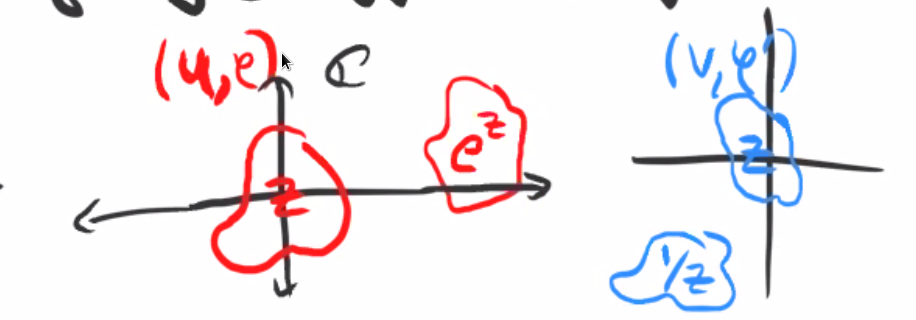

In this case
$$\begin{align*} \operatorname{Hol}({\mathbb{C}})_0 = \left\{{\phi = \sum_{i>0}c_i z^i ~{\text{s.t.}}~\phi \text{ has a positive radius of convergence}}\right\} .\end{align*}$$

An element $f\in \mathcal{F}(U)$ is called a *section* over $U$, and elements of the stalk $f\in \mathcal{F}_p$ are called *germs* at $p$.

# Thursday, October 01

## Stalks and Localizations

If $X$ is an affine variety with the zariski topology, $\mathcal{O}_X$ is a sheaf of regular functions, where we recall $\mathcal{O}_X(U)$ are the functions $\phi: U\to k$ that are locally a fraction.

Recall that the *stalk* of a sheaf $\mathcal{F}$ at a point $p\in X$, is defined as
$$\begin{align*} \mathcal{F}_p \mathrel{\vcenter{:}}=\left\{{(U, \phi) ~{\text{s.t.}}~p\in U \text{ open },\, \phi \in \mathcal{F}(U)}\right\}/\sim .\end{align*}$$
where $(U, \phi) \sim (U', \phi')$ if there exists a $p\in W \subset U\cap U'$ such $\phi, \phi'$ restricted to $W$ are equal.

Recall that a *local ring* is a ring with a unique maximal ideal ${\mathfrak{m}}$. Given a prime ideal ${\mathfrak{p}}\in R$, so $ab\in {\mathfrak{p}}\implies a,b\in {\mathfrak{p}}$, the complement $R\setminus P$ is closed under multiplication. So we can localize to obtain $R_{\mathfrak{p}}= \left\{{a/s ~{\text{s.t.}}~s\in R\setminus P, a\in R}\right\}/\sim$ where $a'/s' \sim a/s$ iff there exists a $t\in R\setminus P$ such that $t(a's - as') = 0$.

Note that $R_f$ is localizing at the powers of $f$, whereas $R_{\mathfrak{p}}$ is localizing at the *complement* of ${\mathfrak{p}}$.

Since maximal ideals are prime, we can localize any ring $R$ at a maximal ideal $R_{\mathfrak{m}}$, and this will be a local ring. Why? The ideals in $R_{\mathfrak{m}}$ biject with ideals in $R$ contained in ${\mathfrak{m}}$. Thus all ideals in $R_{\mathfrak{m}}$ are contained in the maximal ideal generated by ${\mathfrak{m}}$, i.e. ${\mathfrak{m}}R_{\mathfrak{m}}$.

Let $X$ be an affine variety. The stalk of the sheaf of regular functions ${\mathcal{O}}_{X, p} \mathrel{\vcenter{:}}=({\mathcal{O}}_X)_p$ is isomorphic to the localization $A(X)_{{\mathfrak{m}}_p}$ where ${\mathfrak{m}}_p \mathrel{\vcenter{:}}= I(\left\{{p}\right\})$.

We can write
$$\begin{align*} A(X)_{{\mathfrak{m}}_p} \mathrel{\vcenter{:}}=\left\{{{g\over f} ~{\text{s.t.}}~g\in A(X),\, f\in A(X)\setminus{\mathfrak{m}}_p}\right\} / \sim \\ \text{ where } g_1/f_1 \sim g_2/f_2 \iff \exists h(p) \neq 0 \text{ where }0 = h(f_2 g_1 - f_1 g_2) .\end{align*}$$
where the $f$ are regular functions on $X$ such that $f(p) = 0$.

We can also write
$$\begin{align*} {\mathcal{O}}_{X, p} \mathrel{\vcenter{:}}=\left\{{(U, \phi) ~{\text{s.t.}}~p\in U,\, \phi \in {\mathcal{O}}_X(U) }\right\} /\sim \\ \text{ where } (U, \phi) \sim (U', \phi') \iff \exists p\in W \subset U\cap U' \text{ s.t. } {\left.{\phi}\right|_{W}} = {\left.{\phi'}\right|_{W}} .\end{align*}$$

So we can define a map
$$\begin{align*} \Phi: A(X)_{{\mathfrak{m}}_p} &\to {\mathcal{O}}_{X, p} \\ {g\over f} &\mapsto \qty{D_f, {g\over f}} .\end{align*}$$

**Step 1:** There are equivalence relations on both sides, so we need to check that things are well-defined.

We have
$$\begin{align*} g/f \sim g'/f' &\iff \exists g \text{ such that } h(p) \neq 0,\, h(gf' - g'f)=0 \in A(X) \\ &\iff \text{the functions } {g\over f}, {g' \over f'} \text{ agree on } W\mathrel{\vcenter{:}}= D(f) \cap D(f') \cap D(h) \\ &\implies (D_f, g/f) \sim (D_{f'}, g'/f') ,\end{align*}$$
since there exists a $W\subset D_f \cap D_{f'}$ such that $g/f, g'/f'$ are equal.

**Step 2:** Surjectivity, since this is clearly a ring map with pointwise operations.

Any germ can be represented by $(U, \phi)$ with $\phi \in {\mathcal{O}}_X(U)$. Since the sets $D_f$ form a base for the topology, there exists a $D_f\subset U$ containing $p$. By definition, $(U, \phi) = (D_f, {\left.{\phi}\right|_{D_f}})$ in ${\mathcal{O}}_{X, p}$.

Using the proposition that ${\mathcal{O}}_X(D(f)) = A(X)_f$, this implies that ${\left.{\phi}\right|_{D_f}} = g/f^n$ for some $n$ and $f(p) \neq 0$, so $(U, \phi)$ is in the image of $\Phi$.

**Step 3**: Injectivity. We want to show that $g/f\mapsto 0$ implies that $g/f = 0 \in A(X)_{{\mathfrak{m}}_p}$.

Suppose that $(D_f, g/f) = 0 \in {\mathcal{O}}_{X, p}$ and $(U, \phi) = 0 \in {\mathcal{O}}_{X,p}$, then there exists an open $W\subset D_f$ containing $p$ such that after passing to some distinguished open $D_h\ni p$ such that $\phi = 0$ on $D_h$. Wlog we can assume $\phi = 0$ on $U$, since we could shrink $U$ (staying in the same equivalence class) to make this true otherwise. Then $\phi = g/f$ on $D_h$, using that ${\mathcal{O}}_X(D_f) = A(X)_f$, so $g/f = 0$ here. So there exists a $k$ such that $f^k(g\cdot 1 - 0\cdot f) = 0$ in $A(X)$, so $f^k g=0 \in A(X)_{{\mathfrak{m}}_p}$.

Conclusion:
$$\begin{align*} {\mathcal{O}}_{X, p} \cong A(X)_{{\mathfrak{m}}_p} .\end{align*}$$

Let $X = \left\{{p, q}\right\}$ with the discrete topology with the sheaf $\mathcal{F}$ given by $p\mapsto R, q\mapsto S, X\mapsto R\times S$.

Then $\mathcal{F}_p = R$, since if $U$ is open and $p\in\ U$ then either $U= \left\{{p}\right\}$ or $U = X$. We can check that for $(r, s)$ a section of $\mathcal{F}$, we have an equivalence of germs $(X, (r, s)) \sim (\left\{{p}\right\}, r)$ since $\left\{{p}\right\} \subset X\cap\left\{{p}\right\}$. Here $X$ plays the role of $U$, $\left\{{p}\right\}$ of $U'$, and the last $\left\{{p}\right\}$ the role of $W \subset U\cap U'$.

$$\begin{align*} {\mathcal{O}}_{X, p} &\to A(X) \\ (\left\{{p}\right\}, r) &\mapsto r \\ \mathcal{F}_p &\cong R .\end{align*}$$

Let $M$ be a manifold and consider the sheaf $C^\infty$ of smooth functions on $M$. Then the stalk $C_p^\infty$ at $p$ is defined as the set of smooth functions in a neighborhood of $p$ modulo functions being equivalent if they agree on a small enough ball $B_\varepsilon(p)$. This contains a maximal ideal ${\mathfrak{m}}_p$, the smooth functions vanishing at $p$.

Then ${\mathfrak{m}}_p^2$ is again an ideal, equal to the set $\left\{{f ~{\text{s.t.}}~{\partial}_i {\partial}_j f\mathrel{\Big|}_p = 0,\, \forall i,j}\right\}$. Thus ${\mathfrak{m}}_p/{\mathfrak{m}}_p^2 \cong \left\{{{\partial}_v}\right\}^\vee$, the dual of the set of directional derivatives.

## What’s the Point!

Problem: what should a map of affine varieties be? A bad definition would be just taking the continuous maps: for example, any bijection ${\mathbb{A}}_{\mathbb{C}}^1$ is a homeomorphism in the zariski topology. Why? This coincides with the cofinite topology, and the preimage of a cofinite set is cofinite.

How do we fix this?

1. $f:X\to Y$ is continuous, i.e. $f^{-1} (U)$ is open whenever $U$ is open.
2. Given $U\subset Y$ open and $\phi \in {\mathcal{O}}_Y(U)$, the function $\phi \circ f: f^{-1}(U) \to k$ is regular.

We’ll take this to be the definition of a morphism $X\to Y$.

For smooth manifolds, we also require that there is a pullback that preserves smooth functions:
$$\begin{align*} f^*: C^\infty(U) \to C^\infty(f^{-1}(U)) .\end{align*}$$

# Tuesday, October 06

Note: the sheaf of locally constant functions valued in a set $S$ is written $\underline{\mathbf S}$.

## Gathmann Chapter 4

A **ringed space** is a topological space $X$ together with a sheaf ${\mathcal{O}}_X$ of rings.

1. $X$ an affine variety and ${\mathcal{O}}_X$ its ring of regular functions.
2. $X$ a manifold over ${\mathbb{R}}^n$ with ${\mathcal{O}}_X$ a ring of smooth or continuous functions on $X$.
3. $X = \left\{{p, q}\right\}$ with the discrete topology and ${\mathcal{O}}_X$ given by $p\mapsto R, q\mapsto S$.
4. Let $U\subset X$ an open subset of $X$ an affine variety. Then declare ${\mathcal{O}}_U$ to be ${\left.{OO_X}\right|_{U}}$.

Recall that the restriction of a sheaf $\mathcal{F}$ to an open subset $U\subset X$ is defined by ${\left.{\mathcal{F}}\right|_{U}}(V) = \mathcal{F}(V)$.

Let $X$ be a topological space and $p\in X$ a point. The *skyscraper sheaf at $p$* is defined by
$$\begin{align*} K_p(U) \mathrel{\vcenter{:}}= \begin{cases} K & p\in U \\ 0 & p\not\in U \end{cases} .\end{align*}$$

Convention: we’ll always assume that ${\mathcal{O}}_X$ is a sheaf of functions, so ${\mathcal{O}}_X(U)$ is a subring of all $K{\hbox{-}}$valued functions on $U$. Moreover, $\operatorname{Res}_{UV}$ is restriction of $K{\hbox{-}}$valued functions.

A *morphism of ringed spaces*
$$\begin{align*} (X, {\mathcal{O}}_X) \xrightarrow{f} (Y, {\mathcal{O}}_Y) \end{align*}$$
is a continuous map $X\to Y$ such that for all opens $U \subset Y$ and any $\phi \in {\mathcal{O}}_Y(U)$, the pullback satisfies $f^* \phi \in {\mathcal{O}}_X(f^{-1}(U))$, i.e. the pullback of a regular function is regular.

Note: need convention that ${\mathcal{O}}_X$ is a sheaf of $K{\hbox{-}}$valued functions in order to make sense of pullbacks. In general, for schemes, need some analog of $f^*: {\mathcal{O}}_X(V) \to {\mathcal{O}}_X(U)$.

Let $X = {\mathbb{A}}^1/K$ and $U = D(f)$ for $f(x) =x$, then $D(f) = {\mathbb{A}}^1\setminus\left\{{0}\right\}$. Then $U\hookrightarrow X$ is continuous. Given an open set $D(f) \subset {\mathbb{A}}^1$, we have
$$\begin{align*} {\mathcal{O}}_{{\mathbb{A}}^1}(D(f)) \mathrel{\vcenter{:}}=\left\{{g/f^n ~{\text{s.t.}}~g\in K[x]}\right\} .\end{align*}$$
We want to show that $\iota: (U, {\mathcal{O}}_U) \hookrightarrow(X, {\mathcal{O}}_X)$ is a morphism of ringed spaces where ${\mathcal{O}}_U(V) = {\mathcal{O}}_X(V)$. Does $\iota^*$ pull back regular functions to regular functions? Yes, since $\iota^{-1} (D(f)) = D(xf)$ and $g/f^n \in {\mathcal{O}}_U(\iota^{-1}(D(f)))$.

A non-example: take
$$\begin{align*} h: {\mathbb{A}}^1 &\to {\mathbb{A}}^1 \\ x & \mapsto \begin{cases} x & x \neq \pm 1 \\ -x & x= \pm 1 \end{cases} .\end{align*}$$
This is continuous because the zariski topology on ${\mathbb{A}}^1$ is the cofinite topology (since the closed sets are finite), so any injective map is continuous since inverse images of cofinite sets are again cofinite.

Question: Does $h$ define a morphism of ringed spaces? I.e., is the pullback of a regular function on an open still regular? Take $U = {\mathbb{A}}^1$ and the regular function $x\in {\mathcal{O}}_{{\mathbb{A}}^1}({\mathbb{A}}^1)$. Then $h^*x = x\circ h$, so
$$\begin{align*} (x\circ h)(p) = \begin{cases} p & p\neq \pm 1 \\ -p & p= \pm 1 \end{cases} \not \in K[x] \end{align*}$$
since this is clearly not a polynomial: if two polynomials agree on an infinite set of points, they are equal.

Consider $\iota: ({\mathbb{R}}^2, C^\infty) \hookrightarrow({\mathbb{R}}^3, C^\infty)$ is the inclusion of a coordinate hyperplane. To say that this is a morphism of ringed spaces, we need that for all $U\subset {\mathbb{R}}^3$ open and $f:U\to {\mathbb{R}}$ a smooth function, we want $i^* f\in C^\infty (\iota^{-1}(U))$. But this is the same as $f\circ \iota \in C^\infty({\mathbb{R}}^2\cap U)$, which is true.

1. They can be composed: if $\phi \in {\mathcal{O}}_Z(U)$, then $g^* \phi \in {\mathcal{O}}_Y(g^{-1}(U))$ and so $f^* g^* \phi \in {\mathcal{O}}_X(f^{-1} g^{-1} (U))$.
2. The identity is a morphism.

Thus ringed spaces form a category, since composition is associative.

Let $f:X\to Y$ be a continuous map between ringed spaces. Assume there exists an open cover $\left\{{U_i}\right\}_{i\in I}\rightrightarrows X$ such that ${\left.{f}\right|_{U_i}}$ is a morphism, then $f$ is a morphism.

Slogan: it suffices to check a morphism on an open cover.

Part a: Need to check that $f$ is continuous, can compute
$$\begin{align*} f^{-1}(V) = \bigcup_{i\in I} U_i \cap f^{-1}(V) = \bigcup_{i\in I} {\left.{f}\right|_{U_i}}^{-1} (V) .\end{align*}$$
but the later is open as a union of open sets, where each constituent set is open by assumption.

> Will finish proof next time.

# Thursday, October 08

Let $f:X\to Y$ be a map of ringed spaces such that there exists an open cover $U_i\rightrightarrows X$ such that ${\left.{f}\right|_{U_i}}$ is a morphism of ringed spaces. Then $f$ itself is a morphism is a morphism of ringed spaces.

Recall that we proved part (a).

We want to show that $f^*$ sends sections of ${\mathcal{O}}_Y$ to sections of ${\mathcal{O}}_X$ (e.g. regular functions pullback). Let $V\subset Y$ be open and $\phi \in {\mathcal{O}}_Y(V)$, then
$$\begin{align*} {\left.{f^* \phi}\right|_{U_i \cap f^{-1} (V)}} \qty{ {\left.{f^* \phi}\right|_{U_i \cap f^{-1} (V)}} }^* \phi \in {\mathcal{O}}_X(U_i f^{-1} (V)) .\end{align*}$$

Since pullback commutes with restriction, $f^* \phi$ is the unique $k{\hbox{-}}$valued function for which
$$\begin{align*} {\left.{f^* \phi}\right|_{U_i \cap f^{-1} V}} = {\left.{f}\right|_{U_i\cap f^{-1} V}}^* \phi .\end{align*}$$
and all of the latter functions agree on overlaps $U_i \cap U_j$. This by unique gluing, $f^* \phi \in {\mathcal{O}}_X(f^{-1}(V))$.

Let $U\subset X$ be open in an affine variety and let $Y\subset {\mathbb{A}}^n$ be another affine variety. Then the morphisms $U\to Y$ of ringed spaces are the maps of the form $f = {\left[ {f_1, \cdots, f_n} \right]}: U\to {\mathbb{A}}^n$ such that $f(U) \subset Y$ and $f_i \in {\mathcal{O}}_X(U)$ for all $i$.

$\implies$: Assume that $f: U\to Y$ is a morphism. Then the coordinate functions $Y\xrightarrow{y_i} {\mathbb{A}}_1$ are regular functions, since they generate ${\mathcal{O}}_Y(Y) = k[y_1, \cdots, y_n]/I(Y)$. Then $f^* y_i$ is a regular function, so define $f_i \mathrel{\vcenter{:}}= f^* y_i$. But then $f = {\left[ {f_1, \cdots, f_n} \right]}$.

$\impliedby$: Conversely suppose $f \mathrel{\vcenter{:}}={\left[ {f_1, \cdots, f_n} \right]}: U\to Y \subset {\mathbb{A}}^n$ is a map such that $f_i \in {\mathcal{O}}_U(U)$. We want to show that $f$ is a morphism, i.e. that the pullback of every regular function is regular. We thus need to show

1. $f$ is continuous, and
2. $f^*$ pulls back regular functions.

For 1, suppose $Z$ is closed, then it suffices to show $f^{-1} (Z)$ is closed. Then $Z = V(g_1, \cdots, g_n)$ for some $g_i \in A(Y)$. So we can write
$$\begin{align*} f^{-1} (Z) = \left\{{ x\in U ~{\text{s.t.}}~g_i(f_1(x), \cdots, f_n(x) ) = 0\, \forall i }\right\} .\end{align*}$$
The claim is that the functions $g_i$ are regular, i.e. in ${\mathcal{O}}_U(U)$, because the $g_i$ are polynomials in regular functions, which form a ring.

This is the common vanishing locus of $m$ regular functions on $U$. By lemma 3.4, the vanishing locus of a regular function is closed, so $f^{-1} (Z)$ is closed.

For 2, let $\phi \in {\mathcal{O}}_Y(W)$ be a regular function on $W\subset Y$ open. Then
$$\begin{align*} f^* \phi = \phi \circ f: f^{-1} (W) &\to K \\ x &\mapsto \phi(f_1(x), \cdots, f_n(x)) .\end{align*}$$
We want to show that this is a regular function. Since the $f_i$ are regular functions, they are locally fractions, so for all $x\in f^{-1} (W)$ there is a neighborhood of $U_x\ni x$ such that (by intersecting finitely many neighborhoods) all of the $f_i$ are fractions $a_i/b_i$.

Then at a point $p = {\left[ {f_i(x)} \right]}$ in the image, there exists an open neighborhood $W_p$ in $W$ such that $\phi = U/V$. But then $\phi{{\left[ {a_i /b_i} \right]}} = (U/V)({\left[ {a_i/b_i} \right]})$, which is evaluation of a fraction of functions on fractions.

Let $Y = V(xy-1)$ and $U\subset {\mathbb{A}}^1$ be $D(x)$, so $U = {\mathbb{A}}^1\setminus\left\{{0}\right\}$. Note that $A(Y) = k[x,y]/\left\langle{xy-1}\right\rangle$ and $A({\mathbb{A}}^1) = k[t]$, and $f_1=t, f_2=t^{-1} \in {\mathcal{O}}_U(U)$. Then
$$\begin{align*} {\left[ {f_1, f_2} \right]}: U &\to Y\subset {\mathbb{A}}^2 \\ p &\mapsto {\left[ {p, {1\over p} } \right]} .\end{align*}$$
Thus the image lies in $Y$.

Conversely, there is a map
$$\begin{align*} V(xy - 1) &\to U = D(0) \subset {\mathbb{A}}^1 \\ {\left[ {x, y} \right]} &\mapsto x .\end{align*}$$
This a morphism from $V(xy - 1)$ to ${\mathbb{A}}^1$, since the coordinates are regular functions. Since the image is contained in $U$, the definitions imply that this is in fact a morphism of ringed spaces. We thus have maps $U\xrightarrow{{\left[ {t, t^{-1} } \right]}} V(xy-1)$ and $V(xy-1) \xrightarrow{x} U$ which are mutually inverse, so these are isomorphic as ringed spaces.

Thus maps of affine varieties (or their open subsets) are given by functions whose coordinates are regular.

Let $X, Y$ be affine varieties, then there is a correspondence
$$\begin{align*} \left\{{\substack{\text{Morphisms } X\to Y }}\right\} &\iff \left\{{\substack{k{\hbox{-}}\text{algebra morphisms } A(Y) \to A(X)}}\right\} \\ X\to Y &\mapsto A(Y) \to A(X) \\ f &\mapsto f^* {\mathcal{O}}_Y(Y) = {\mathcal{O}}_X(X) .\end{align*}$$

We have a map in the forward direction. Conversely, given a $k{\hbox{-}}$algebra morphism $g:A(Y) \to A(X)$, we need to construct a morphism $f$ such that $f^* = g$. Let $Y\subset {\mathbb{A}}^n$ with coordinate functions $y_1, \cdots, y_n$. Then $f_i = g(y_i) \in A(X) = {\mathcal{O}}_X(X)$. Set $f = {\left[ {f_1, \cdots, f_n} \right]}$. Then by the proposition, $f$ is a morphism to ${\mathbb{A}}^n$.

Let $h\in A({\mathbb{A}}^n)$, then

$$\begin{align*} (f^*h)(x) &= h(f(x)) \\ &= h({\left[ {f_1(x) , \cdots, f_n(x)} \right]}) \\ &= h(g(y_1), \cdots, g(y_n)) \\ &= g(h)(x) \qquad\text{since $g$ is an algebra morphism, $h$ is a polynomial} \end{align*}$$
which follows since $f_i(x) = g(y_i)(x)$, where $g:A(Y) \to A(X)$. So $f^*(h) = g(h)$ for all $h\in A({\mathbb{A}}^n)$, so the pullback of $f$ is $g$. We now need to check that it’s contained in the image. Let $h\in I(Y)$, then $f^*(h) = g(h) = 0$ since $h = 0 \in A(Y)$. So $\operatorname{im}f \subset Y$. Since the coordinate $f_i$ are regular, this is a morphism, and we have $f^* = g$ as desired.

Isomorphisms are not necessarily bijective morphisms. Let $X = V(y^2 - x^3) \subset {\mathbb{A}}^2$.

Then there is a morphism
$$\begin{align*} \phi: {\mathbb{A}}^1 &\to X \\ t &\mapsto {\left[ {t^2, t^3} \right]} ,\end{align*}$$
since the coordinates $t^2, t^3$ are regular functions. Then $\phi$ is a bijection, since we can define a piecewise inverse
$$\begin{align*} \phi^{-1}: X &\to {\mathbb{A}}^1 \\ {\left[ {x, y} \right]} &\mapsto \begin{cases} y/x & x\neq 0 \\ 0 & \text{else} \end{cases} .\end{align*}$$
However, $\phi ^{-1}$ is not a morphism. For instance, pulling back the function $t$ yields $\qty{\phi ^{-1} }^* t \not \in A(X)$, since it is equal to the map ${\left[ {x, y} \right]} \mapsto y/x$ for $x\neq 0$ and $0$ if $x=y=0$, which is not a regular function.

Since $\phi$ is a morphism, we can consider the corresponding map of $k{\hbox{-}}$algebras
$$\begin{align*} \phi^*: A(X) &\to A({\mathbb{A}}^1) \\ k[x, y]/\left\langle{y^2 - x^3}\right\rangle &\mapsto k[t] \\ x & \mapsto t^2 \\ y &\mapsto t^3 .\end{align*}$$

# Tuesday, October 13

Last time: proved that if $X, Y$ are affine varieties then there is a bijection
$$\begin{align*} \left\{{\substack{\text{Morphisms} \\ f:X\to Y}}\right\} &\iff \left\{{\substack{\text{$k{\hbox{-}}$algebra morphisms}\\ A(Y) \to A(X)}}\right\} \\ f & \mapsto f^*: {\mathcal{O}}_Y(Y) \to {\mathcal{O}}_X(X) .\end{align*}$$

A morphism $f:X\to Y$ is by definition a morphism of ringed spaces where ${\mathcal{O}}_X, {\mathcal{O}}_Y$ are the sheaves of regular functions.

This shows $X\cong Y$ as ringed spaces iff $A(X) \cong A(Y)$ as $k{\hbox{-}}$algebras.

Take
$$\begin{align*} f: {\mathbb{A}}^1 &\to V(y^2 - x^3) \subset {\mathbb{A}}^2\\ t &\mapsto (t^2, t^3) .\end{align*}$$
This is a morphism by proposition 4.7.

We then get a map on algebras
$$\begin{align*} f^*: A(V(y^2 - x^3)) = k[x, y] / \left\langle{y^2 - x^3}\right\rangle &\to k[t] \\ x & \mapsto t^2 \\ y & \mapsto t^3 ,\end{align*}$$
but even though $f$ is a bijective morphism, it’s not an isomorphism of ringed spaces. This can be seen from the fact that the image doesn’t contain $t$.

> Review of introductory category theory.

We’ll define a category $\mathrm{AffVar}_k$ whose objects are affine varieties over $k$ and morphisms in $\hom(X, Y)$ will be morphisms of ringed spaces. There is a contravariant functor $A$ into reduced finitely generated $k{\hbox{-}}$algebras which sends $X$ to $A(X)$ and sends morphisms $f:X\to Y$ to their pullbacks $f^*:A(Y) \to A(X)$, where “reduced” denotes the fact that there are no nilpotents.

> Review of the universal property of the product.

If we have $X,Y$ affine varieties, we take $X\times Y$ to be the categorical product instead of the underlying product of topological spaces. We have
$$\begin{align*} A(X\times Y) \cong A(X) \otimes_k A(Y) \cong k[x_1, \cdots, x_n, y_1, \cdots, y_m] / I(X) \otimes 1 + 1 \otimes I(Y).\end{align*}$$
This recovers the product, since if we have

[figure not shown]

where $H = (f, g)$.

Products of spaces are sent to the tensor product of $k{\hbox{-}}$algebras, i.e. pullbacks are sent to pushouts.

Note that the groupoid associated to a group does not have products: there can only be one element, but the outer triangles will not necessarily simultaneously commute.

# Thursday, October 15

## End of Chapter 4

Recall the proposition: morphisms between affine varieties are in bijection with $k{\hbox{-}}$algebra morphisms between their coordinate rings. As a result, we’ll redefine an affine variety to be a ringed space isomorphic to an affine variety.

This allows you to say that affine varieties embedded in different ways are the same.

${\mathbb{A}}^2$ vs $V(x) \subset {\mathbb{A}}^n$. In fact, the map
$$\begin{align*} f: {\mathbb{A}}^2 &\to {\mathbb{A}}^3 (y,z) &\mapsto (0, y, z) .\end{align*}$$
This is continuous and the pullback of regular functions are again regular.

With the new definition, there is a bijection between affine varieties up to isomorphisms and finitely generated $k{\hbox{-}}$algebras up to algebra isomorphism.

Let $D(f) \subset X$ be a distinguished open, then $D(f)$ is a ringed space since $(X, {\mathcal{O}}_X)$ is and we can restrict the structure sheaf.

Set
$$\begin{align*} Y \mathrel{\vcenter{:}}=\left\{{(x, t) \in X\times{\mathbb{A}}^1 ~{\text{s.t.}}~tf(x) = 1}\right\} \subset X\times{\mathbb{A}}^1 .\end{align*}$$
This is an affine variety, since $Y = V(I + \left\langle{ft-1}\right\rangle)$. This is isomorphic to $D(f)$ by the map
$$\begin{align*} Y &\to D(f) (x, t) &\mapsto x .\end{align*}$$
with inverse $x \mapsto (x, {1\over f(x)})$.

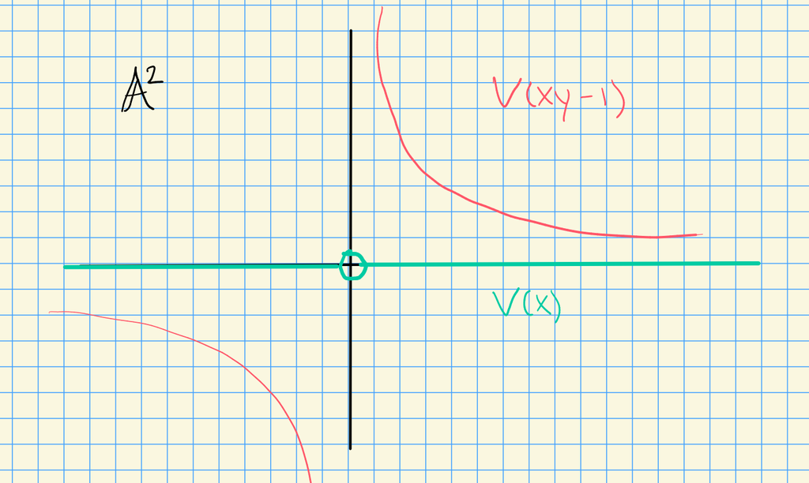

Image

Note that $\pi: X\times{\mathbb{A}}^1 \to X$ is regular, using prop 3.8: if the coordinates of a map are regular functions, then the entire map is a morphism of ringed spaces. We can then note that $1\over f(x)$ is regular on $D(f)$, since $f\neq 0$ there.

${\mathbb{A}}^2 \setminus\left\{{0}\right\}$ is not an affine variety. Note that this is also not a distinguished open.

We showed on a HW problem that the regular functions on ${\mathbb{A}}^2\setminus\left\{{0}\right\}$ are $k[x, y]$, which are also the regular functions on ${\mathbb{A}}^2$. So there is a map inducing a pullback
$$\begin{align*} \iota: {\mathbb{A}}^2\setminus\left\{{0}\right\}&\to {\mathbb{A}}^2 \\ \iota^* k[x, y] \xrightarrow{\sim} k[x, y] .\end{align*}$$
Note that $\iota^*$ is an isomorphism on the space of regular functions, but $\iota$ itself is not an isomorphism of topological spaces. Why? $i^{-1}$ is not defined at zero.

## Chapter 5

A *prevariety* is a ringed spaced $X$ with a finite open cover by affine varieties. This is a topological space $X$ with an open cover $\left\{{U_i}\right\}_{i=1}^n \rightrightarrows X$ such that $(U_i, {\left.{{\mathcal{O}}_X}\right|_{U_i}} )$ is isomorphic to an affine variety. We’ll call ${\mathcal{O}}_X$ the sheaf of *regular functions* and $U_i\subset X$ *affine open sets*.

One way to construct prevarieties from affine varieties is by *gluing*:

let $X_1, X_2$ be prevarieties which are themselves actual varieties. Let $U_{12} \subset X_1, U_{21} \subset X_2$ be opens and $f: U_{12} \to U_{21}$ an isomorphism of ringed spaces.

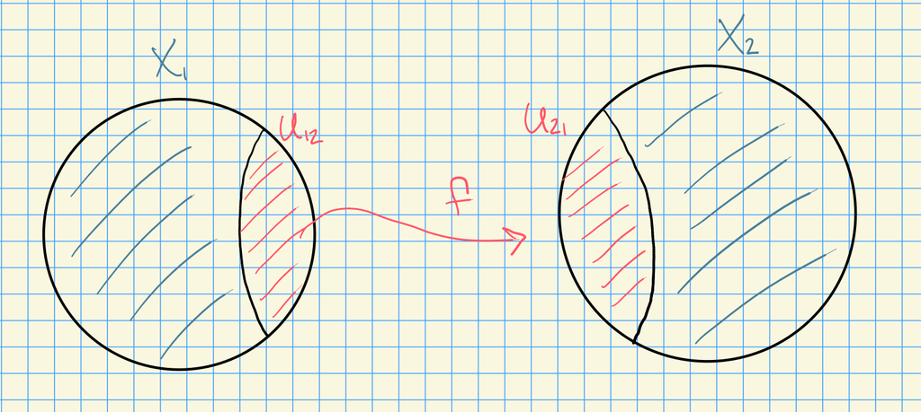

Image

As a set, take $X = X_1 {\coprod}X_2/\sim$ where $a\sim f(a)$ for all $a\in U_{12}$. As a topological space, $U \subset X$ is open iff $U_i \mathrel{\vcenter{:}}= U\cap X_i$ are open in $X_i$. As a ringed space, we take ${\mathcal{O}}_X(U) \mathrel{\vcenter{:}}=\left\{{\phi: U\to k ~{\text{s.t.}}~{\left.{\phi}\right|_{U_i}} \in {\mathcal{O}}_{X_i}}\right\}$.

The prototypical example is ${\mathbb{P}}^1/k$ constructed from two copies of ${\mathbb{A}}^1/k$. Set $X_1 = {\mathbb{A}}^1, X_2 = {\mathbb{A}}^2$, with $U_{12} \mathrel{\vcenter{:}}= D(x) \subset X_1$ and $U_{21} \mathrel{\vcenter{:}}= D(y) \subset X_2$. Then let
$$\begin{align*} f: U_{12} &\to U_{21} \\ x & \mapsto {1\over x} .\end{align*}$$
This defines a regular function on $U_{12}$ so defines a morphism $U_{12} \xrightarrow{\sim} {\mathbb{A}}^1$.

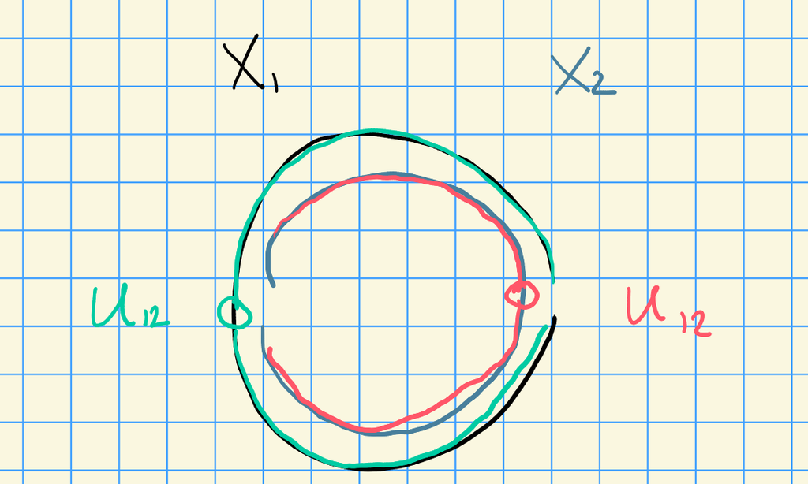

Image

Over ${\mathbb{C}}$, topologically this yields a sphere

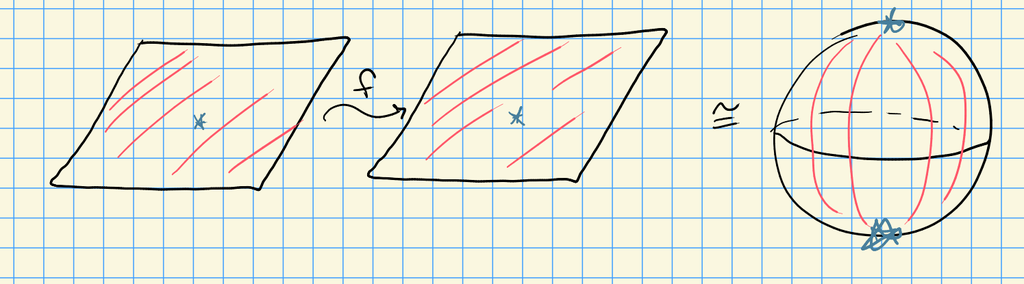

Image

Given a ringed space $X = X_1\cup X_2$ with a structure sheaf ${\mathcal{O}}_X$, what is ${\mathcal{O}}_X(X)$? By definition, it’s

$$\begin{align*} {\mathcal{O}}_X(X) \mathrel{\vcenter{:}}=\left\{{\phi: X\to k ~{\text{s.t.}}~{\left.{\phi}\right|_{X_1}}, {\left.{\phi}\right|_{X_2}} \text{ are regular} }\right\} .\end{align*}$$

Then if ${\left.{\phi}\right|_{X_1}} = f(x)$ and ${\left.{\phi}\right|_{X_2}} = g(y)$, we have $y=1/x$ on the overlap and so ${\left.{f(x)}\right|_{D(x)}} = {\left.{g(1/x)}\right|_{D(x)}}$. Since $f, g$ are rational functions agreeing on an infinite set, $f(x) = g(1/x)$ both being polynomial forces $f = g = c$ for some constant $c \in k$. Thus ${\mathcal{O}}_X(X) = k$.

What about ${\mathcal{O}}_X(X_1)$? This is just $k[x]$, and similarly ${\mathcal{O}}_X(X_2) = k[y]$. We can also consider ${\mathcal{O}}_X(X_1\cap X_2) = D(x) \subset X$, so this yields $k[x, 1/x]$. We thus have a diagram

[figure not shown]

# Tuesday, October 20

## Gluing Two Opens

Recall that a *prevariety* is a ringed space that is locally isomorphic to an affine variety, where we recall that $(X, {\mathcal{O}}_X)$ is *locally isomorphic* to an affine variety iff there exists an open cover $U_i \rightrightarrows X$ such that $(U_i, {\mathcal{O}}_{U_i})$.

We found one way of producing these: the gluing construction. Given two ringed spaces $(X_1, {\mathcal{O}}_{X_1})$ and $(X_2, {\mathcal{O}}_{X_2})$ and open sets $U_{12} \in X_1$ and $U_{21} \in X_2$ and an isomorphism $(U_{12}, {\mathcal{O}}_{U_{12}}) \xrightarrow{f} (U_{21}, {\mathcal{O}}_{U_{21}})$, we defined

- The topological space as $X_1 {\coprod}_f X_2$
- The sheaf of rings as ${\mathcal{O}}_X = \left\{{\phi:U\to k ~{\text{s.t.}}~{\left.{\phi}\right|_{U\cap X_i}} \text{ is regular for } i=1,2 }\right\}$.

${\mathbb{P}}^1/k = X_1 \cup X_2$ where $X_1 \cong {\mathbb{A}}^1, X_2 \cong {\mathbb{A}}^2$. Take $U_{12} = D(x)$ and $U_{21} = D(y)$ with
$$\begin{align*} f: U_{12} &\to U_{21} \\ x &\mapsto {1\over x} = y .\end{align*}$$

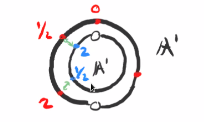

Supposing $\operatorname{ch}(k) \neq 2$. Note that for ${\mathbb{C}}$ this recovers $S^2$ in the classical topology.

Let $X_i = {\mathbb{A}}^1$ and $U_{12} = D(x), U_{21} = D(y)$ with
$$\begin{align*} f: U_{12} &\to U_{21} \\ x &\mapsto x=y .\end{align*}$$

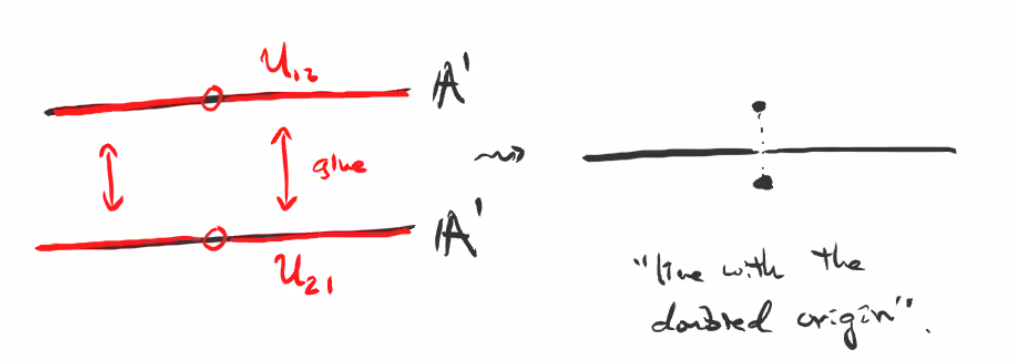

Line with the doubled origin.

Then ${\mathcal{O}}_X = \left\{{\phi: X\to k ~{\text{s.t.}}~{\left.{\phi}\right|_{X_i}} \text{ is regular}}\right\} \cong k[x]$.

## More General Gluing

Now we want to glue more than two open sets. Let $I$ be an indexing set for prevarieties $X_i$. Suppose that for an ordered pair $(i, j)$ we have open sets $U_{ij} \subset X_i$ and isomorphisms $f_{ij}: U_{ij} \xrightarrow{\sim} U_{ji}$ such that

1. $f_{ji} = f_{ij}^{-1}$
2. $f_{jk} \circ f_{ij} = f_{ik}$ (cocycle condition)

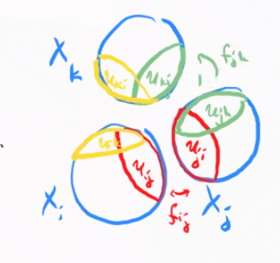

Opens with isomorphisms.

Then the gluing construction is given by

1. $X\mathrel{\vcenter{:}}={\coprod}X_i/\sim$ where $x\sim f_{ij}(x)$ for all $i,j$ and all $x\in U_{ij}$.
2. ${\mathcal{O}}_x(U) \mathrel{\vcenter{:}}=\left\{{\phi:U\to k ~{\text{s.t.}}~{\left.{\phi}\right|_{U\cap X_i}} \in {\mathcal{O}}_{X_i} }\right\}$.

Every prevariety arises from the gluing construction applied to $X_i$ affine varieties, since a prevariety $(X, {\mathcal{O}}_X)$ by definition has an open affine cover $X_i \rightrightarrows X$ and $X$ is the result of gluing the $X_i$s by the identity.

Let $X_1 = X_2 = X_3 = {\mathbb{A}}^2/k$. Glue by the following instructions:

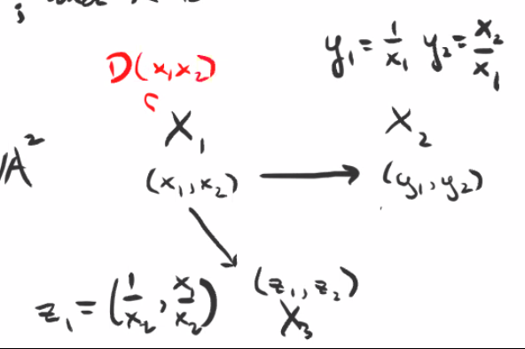

The map not shown is whatever formula is necessary to make the diagram commute.

Here

- $(y_1, y_2) = (1/x_1, x_2/x_1)$
- $(z_1, z_2) = (1/x_2, x_1/x_2)$
- $U_{12} = D(x_1)$
- $U_{21} = D(x_2)$.

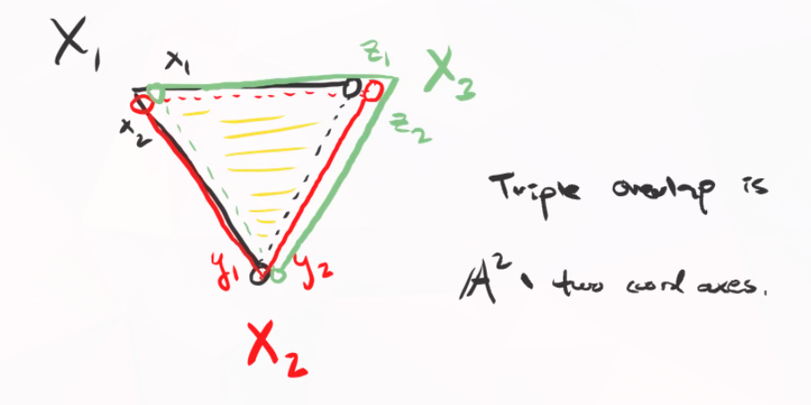

Yields ${\mathbb{P}}^2$

Here $X_1 = [1: y/x: z/x]$, $X_2 = [x/y: 1: z/y]$.

From Gathmann 5.10, open and closed subprevarieties. Let $X$ be a prevariety and suppose $U\subset X$ is open. Then $(U, {\mathcal{O}}_U)$ is a prevariety where ${\mathcal{O}}_U = {\left.{{\mathcal{O}}_X}\right|_{U}}$. How can we write $U$ as (locally) an affine variety?

Since the $U_i$ are covered by distinguished opens $D_{ij}$ in $X_i$ where $X = \cup X_i$ with $X_i$ affine varieties, we can write $U = \bigcup_i U_i = \bigcup_{i, j} D_{ij}$.

Let $Y\subset X$ be a closed subset of a prevariety $X$. We need to define ${\mathcal{O}}_Y(U)$ for all $U\subset Y$ open, so we set
$$\begin{align*} {\mathcal{O}}_Y(U) = \left\{{\phi: U\to k ~{\text{s.t.}}~\forall p\in U, \, \exists V_p \text{ with } p\in V_p \subset_{\text{open}} X \text{ and } \psi\in {\mathcal{O}}_X(V_p) \text{ s.t. } {\left.{\psi}\right|_{U\cap V}} \phi }\right\} .\end{align*}$$

What’s the picture?

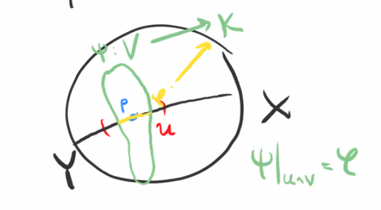

Sheaf for a closed subset.

It’s an exercise to show that this is a prevariety.

If $U\subset X$ is an open subprevariety or $Y\subset X$ is a closed subprevariety, then the inclusions are morphisms. We’d need to show that a pullback of a function is regular, but this is set up by definition.

Define $\tilde {\mathcal{O}}_X(U)$ as the set of *all* functions $U\to k$. Then the inclusion $(X, {\mathcal{O}}_X) \hookrightarrow(X, \tilde {\mathcal{O}}_X)$ given by the identity on $X$ is a morphism, but the identity in the reverse direction is not.

# Thursday, October 22

Consider ${\mathbb{A}}^1$, whose polynomial functions are $k[x]$. Consider now $D(x) \subset {\mathbb{A}}^1$, which is equal to the affine variety $V(xy-1)$. Then the polynomial functions on $D(x)$ are $k[x, y] / \left\langle{xy-1}\right\rangle \cong k[x, x^{-1} ]$.

Recall that a *prevariety* is a ringed space $(X, {\mathcal{O}}_X)$ such that $X$ has a finite open cover by affine varieties $(U_i, {\left.{{\mathcal{O}}_X}\right|_{U_i}})$, and a *morphism* of prevarieties is a morphism of ringed spaces. We saw that one can construct prevarieties by gluing finite collections of prevarieties or affine varieties along open sets, and all prevarieties arise this way.

The product is unique up to unique isomorphism, i.e. there is a unique isomorphism between any two products.

Standard!

Consider ${\mathbb{A}}^1 \times {\mathbb{A}}^1$, then the product is (and should be) ${\mathbb{A}}^2$, but ${\mathbb{A}}^2$ does not have the product topology. The open set $D(x-y)$ is not covered by products of open sets.

> This happens because the Zariski topology is too weak.

Strategy to fix: use gluing. Let $X, Y$ be prevarieties and $\left\{{U_i}\right\}, \left\{{V_i}\right\}$ be open affine covers of $X$ and $Y$ respectively. We can construct the product $U_i \times V_j \subset {\mathbb{A}}^{n+m}$, which is an affine variety and satisfies the universal property for products. We then glue two such products $U_{i_1} \times V_{j_1}$ and $U_{i_2} \times V_{j_2}$ along their common open subset in $\qty{U_{i_1}\cap U_{i_2} }\cap\qty{V_{j_1} \cap V_{j_2}} \subseteq X\times Y$.

Let $\tilde U \mathrel{\vcenter{:}}= U_{i_1} \cap U_{i_2} \times V_{j_1} \cap V_{j_2}$, we then need that

$$\begin{align*} (\tilde U, {\left.{ {\mathcal{O}}_{U_{i_1} \times V_{j_1}} }\right|_{\tilde U}} ) \cong (\tilde U, {\left.{ {\mathcal{O}}_{U_{i_2} \times V_{j_2}} }\right|_{\tilde U}} ) .\end{align*}$$
This follows from the universal property of products, since the open set $(U\times V, {\left.{ {\mathcal{O}}_{X\times Y} }\right|_{U\times V}} )$ is a categorical product of ringed spaces, and the identity provides a unique isomorphism. By the gluing construction, this produces a ringed space $(X\times Y, {\mathcal{O}}_{X\times Y})$, we just need to check that this satisfies the universal property. We have projections $\pi_X, \pi_Y$ set-theoretically, which restrict to morphisms on every $U_i \times V_j$. For any prevariety $Z$, we get a unique set map $h:Z\to X\times Y$ which commutes, so it suffices to check that $h$ is a morphism of ringed spaces.

So consider $h^{-1} (U_i \times V_j) \subset Z$, which is an open subset of $Z$ given by $f^{-1}(U) \times f^{-1}(V)$. Take an open cover and let $W$ be an element in it. We can then restrict $f$ and $g$ to get ${\left.{f}\right|_{W}}:W\to U_i$ and ${\left.{g}\right|_{W}}:W\to V_j$ and their product is a morphism of ringed spaces. So $Z$ is covered by open sets for which $h$ is a morphism of ringed spaces, making $h$ itself a morphism.

What was the point of constructing the product? We want some notion analogous to being Hausdorff to distinguish spaces like ${\mathbb{P}}^1/k$ from the line with the doubled origin. The issue is that these spaces with the Zariski topology are never Hausdorff. So we make the following definition:

A prevariety is **separated** iff $X \xhookrightarrow{\Delta_X} X\times X$ is a closed embedding, where $\Delta(x) = (x, x)$ is the diagonal morphism. i.e. $\text{id}_X \times\text{id}_X$.

A **variety** is a separated prevariety.

# Tuesday, October 27

Recall that an affine variety is given by $X = V(I) \subset {\mathbb{A}}^n/k$, and we have sheaves of rings of regular functions ${\mathcal{O}}_X$ on $X$. A prevariety is a ringed space that is covered by finitely many affine spaces. A morphism of prevarieties $f:X\to Y$ is a continuous map such that the pullbacks of regular functions are regular, i.e. for all $\phi \in {\mathcal{O}}_X(U)$ we have $f^* \phi \in {\mathcal{O}}_X(f^{-1} (U) )$. We can form a category $\operatorname{PreVar}_k$ of prevarieties over $k$, where we have several important constructions

1. Gluing
2. Products: Given $X, Y$, there is a unique prevariety $X\times Y$ such that

[figure not shown]

We had an analogue of being Hausdorff: the diagonal $\Delta_X$ is closed.

Glue $D(x) \subset {\mathbb{A}}^1$ to $D(y) \subset {\mathbb{A}}^1$ by the isomorphism
$$\begin{align*} D(x) & \xrightarrow{\sim} D(y) \\ x &\mapsto y .\end{align*}$$
This yields an affine line with two origins:

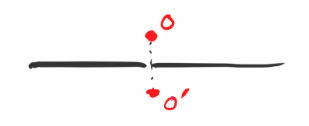

Line with two origins.

Consider the product:

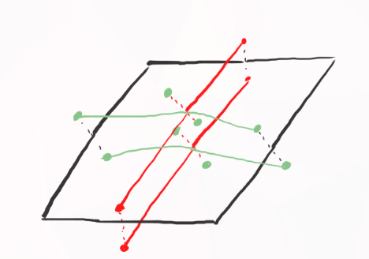

Product of lines with two origins

Since the diagonal is given by $\Delta_X = \left\{{(x, x) ~{\text{s.t.}}~x\in X}\right\}$, we have the following situation in blue:

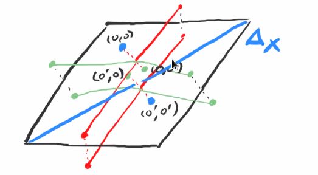

Image

We claim that $\Delta_X$ is not closed, and for example $(0, 0') \in \mkern 1.5mu\overline{\mkern-1.5mu\Delta\mkern-1.5mu}\mkern 1.5mu_X$. Consider $U\times U' \subset X\times X$ where $U, U'$ are the two copies of ${\mathbb{A}}^1$ in $X$. This is an affine open set, since it’s isomorphic to ${\mathbb{A}}^1\times{\mathbb{A}}^1$.

If $\Delta_X$ were closed, then $S \mathrel{\vcenter{:}}=\Delta_X \cap(U\times U') = \left\{{(x, x) ~{\text{s.t.}}~x\neq 0}\right\}$ would be closed in $U\times U'$.

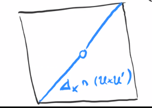

Open diagonal in a product.

This is because any polynomial vanishing on $S$ must vanish at $(0, 0)$, so $S$ is an affine variety. But then $V(I(S)) = \Delta_{{\mathbb{A}}^1}$.

1. Any affine variety is a variety.
2. Open and closed subprevarieties of a variety $X$ are themselves varieties.

Thus it makes since to consider *open* and *closed subvarieties*.

We need to check that $\Delta_X \subset X^2$ is closed for any affine $X\subset {\mathbb{A}}^n$. Note that we can write.
$$\begin{align*} \Delta_X = X^2 \cap V\qty{ \left\{{x_j - y_j ~{\text{s.t.}}~1\leq j \leq n}\right\}} \subset {\mathbb{A}}^n \times{\mathbb{A}}^2 \end{align*}$$

Let $\iota:Y\to X$ be the inclusion of either an open or closed subset. Then we have a morphism $(\iota, \iota): Y^2 \to X^2$ by the universal property. Then $\Delta_Y = (\iota, \iota)^{-1} (\Delta_X)$, so is closed by the continuity of $(\iota, \iota)$ and the fact that $\Delta_X$. Thus $Y$ is a variety.

## Properties of Varieties

Let $f, g: X\to Y$ be morphisms of prevarieties and assume $Y$ is a variety.

1. The graph of $f$, given by $\Gamma_f \mathrel{\vcenter{:}}=\left\{{(x, f(x)) ~{\text{s.t.}}~x\in X}\right\}$, is closed in $X\times Y$.
2. The set $\left\{{x\in X~{\text{s.t.}}~f(x) = g(x)}\right\}$ is closed in $X$.

Consider the product morphism $(f, \text{id}): X\times Y \to Y^2$. Since $\Delta_Y$ is closed, $(f, \text{id})^{-1} (\Delta_Y)$ is closed, and is the locus where $f(x) = y$, so this is $\Gamma_f$.

Consider $(f, g): X\to Y^2$. Since $\Delta_Y \subset Y^2$ is closed,
$$\begin{align*} (f, g)^{-1}(\Delta_Y) = \left\{{x\in X ~{\text{s.t.}}~f(x) = g(x)}\right\} \subset X \end{align*}$$

is closed.

## Chapter 6: Projective Varieties

Note that affine varieties of positive dimension over ${\mathbb{C}}$ are not compact in the classical topology, but *are* compact in the Zariski topology. Similarly, they are Hausdorff classically, but not in the Zariski topology. We want to find notions equivalent to Hausdorffness and compactness in the classical setting, which end up also applying to varieties. The fix in the latter case was considering “separatedness”. The fix for compactness will be the following:

A variety $X$ is **complete** iff for any variety $Y$ the projection map $\pi_Y:X\times Y\to Y$ is a closed map, i.e. $\pi_Y(U)$ is closed whenever $U$ is closed.

${\mathbb{A}}^1$ is not complete. Let $Y={\mathbb{A}}^1$ and $Z = V(xy-1)\subset X\times Y$. Then $\pi_Y(Z) = D(y) \subset Y \subset {\mathbb{A}}^1$ is not closed.

# Thursday, October 29

## Projective Space

Let $n\in {\mathbb{N}}$, and define **projective $n{\hbox{-}}$space** over $k$ by
$$\begin{align*} {\mathbb{P}}^n/k = \left\{{\text{lines through the origin in } k^{n+1}}\right\} .\end{align*}$$

For notation, given $L\in {\mathbb{P}}^n/k$, it is spanned by any nonzero points ${\left[ {x_0, \cdots, x_n} \right]} \in L$, and $L$ is uniquely determined by this point up to scaling by elements in $k^{\times}$. In this case, we write $L = {\left[ {x_0: \cdots : x_n} \right]} = {\left[ {\lambda x_0: \cdots : \lambda x_n} \right]}$. We can then define ${\mathbb{P}}^n/k = k^{n+1}\setminus\left\{{0}\right\}/ \sim$ where we mod out by scalar multiplication. We call $[x_1 : \cdots : x_n]$ the *homogeneous coordinates* on ${\mathbb{P}}^n/k$.

Consider the map
$$\begin{align*} {\mathbb{A}}^n \to {\mathbb{P}}^n \\ {\left[ {x_1, \cdots, x_n} \right]} &\mapsto {\left[ {1: x_1 : \cdots : x_n} \right]} .\end{align*}$$
This is injective. Conversely, consider
$$\begin{align*} "D(x_0)" \subset {\mathbb{P}}^n \mathrel{\vcenter{:}}=\left\{{{\left[ {x_0 : \cdots : x_n} \right]} ~{\text{s.t.}}~x_0\neq 0}\right\} .\end{align*}$$
This is a well-defined subset of ${\mathbb{P}}^n$, since it only depends on the equivalence class of a point. In this case, there is a unique $\lambda(x_0, \cdots, x_n)$, namely $\lambda = 1/x_0$, such that each point in this set is of the form ${\left[ {1: {x_1\over x_0} : \cdots : {x_n \over x_0}} \right]}$, yielding a copy of ${\mathbb{A}}^n\subset {\mathbb{P}}^n$ given by points ${\left[ {{x_1\over x_0}, \cdots, {x_n\over x_0}} \right]}$. What is its complement?

It’s given by $\left\{{{\left[ {0: x_1: \cdots : x_n} \right]}}\right\} \subset {\mathbb{P}}^n$, which is equal (as a set) to a copy of ${\mathbb{P}}^{n-1}$ defined by the set of lines in $k^n$ defined by $x_0 = 0$.

Note that ${\mathbb{P}}^1$ contains a copy of ${\mathbb{A}}^1$ where $x_0 \neq 0$ and a second copy where $x_1 \neq 0$, admitting maps
$$\begin{align*} f_1: {\mathbb{A}}^1 &\to {\mathbb{P}}^1 \\ {\left[ {x_0: x_1} \right]} &\mapsto {\left[ {{x_0 \over x_1}} \right]} .\end{align*}$$

and

$$\begin{align*} f_2: {\mathbb{A}}^1 &\to {\mathbb{P}}^1 \\ {\left[ {x_0: x_1} \right]} &\mapsto {\left[ {{x_1 \over x_0}} \right]} ,\end{align*}$$
since every line in ${\mathbb{P}}^1$ has either $x_0\neq 0$ or $x_1 \neq 0$. These two copies cover ${\mathbb{P}}^1$, and the “transition map” is inversion.

More generally, there are $n+1$ inclusions ${\mathbb{A}}^n \hookrightarrow{\mathbb{P}}^n$ given by dividing by the $j$th coordinate, and their union is the entire space. The gluing construction gives ${\mathbb{P}}^n$ the structure of a prevariety: we can consider $D(x_j) \subset {\mathbb{P}}^n$ where each has the structure of a ringed space $({\mathbb{A}}^n, {\mathcal{O}}_{{\mathbb{A}}^n})$. We have $D(x_i) \cap D(x_j) \subset D(x_i)$ is given coordinate $x_k/x_i$ where $k\neq i$, and similarly this is a subset of $D(x_j)$ with coordinates $x_k/x_j$ for $k\neq j$. Their intersection is $D({x_i \over x_j})$, which is a copy of ${\mathbb{A}}^{n-1}$.

Consider ${\mathbb{P}}^1$, then $D(x_0) \cong {\mathbb{A}}^1$ with which contains a copy of ${\mathbb{A}}^1$ with coordinate ring $k{\left[ {{x_1\over x_0}} \right]}$ and a subset $D\qty{x_1\over x_0}$ with coordinate ring $k[y, 1/y]$, and similarly, $D(x_1) \cong {\mathbb{A}}^1$ has coordinate ring $k{\left[ {{x_0\over x_1}} \right]}$ and contains $\supseteq D\qty{x_0\over x_1}$ with coordinate ring $k[z, 1\over z]$. Consider their overlap $D(x_0) \cap D(x_1)$? When do $y, z$ denote the same point in ${\mathbb{P}}^1$? When $y = 1/z$.

We can conclude that the $n+1$ copies $D(x_i) \subset {\mathbb{P}}^n$ are affine varieties isomorphic as ringed spaces on the overlaps, so the gluing construction makes ${\mathbb{P}}^n$ a prevariety.

A polynomial $f$ is homogeneous of degree $f$ is every monomial in $f$ has total degree $d$.

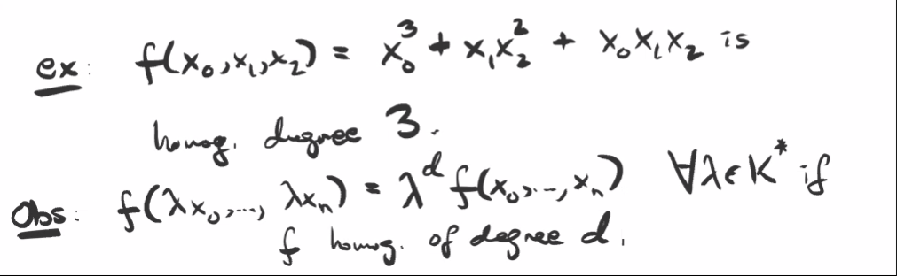

Image

If $f$ is homogeneous, $V(f) \subset {\mathbb{P}}^n$ is a well-defined subset, since $f(x_0, \cdots, x_n) = 0 \iff \lambda^d f(x_0, \cdots, x_n) = 0 \iff f(\lambda x_0, \cdots, \lambda x_n) = 0$.

A graded ring $R$ is a ring $R$ with abelian subgroups $R_d \subset R$ with $R = \bigoplus_{d\geq 0} R_d$ and for all $f\in R_d$ and $g\in R_{d'}$, we have $fg \in R_{d+d'}$ and $R_d + R_{d} \subset R_d$.

# Thursday, November 05

Today: projective spaces. We defined ${\mathbb{P}}^n_{/k} \mathrel{\vcenter{:}}= k^{n+1}\setminus\left\{{0}\right\}/\sim$ where $x\sim \lambda x$ for all $x\in k^{\times}$, which we identified with lines through the origin in $k^{n+1}$. We have homogeneous coordinates $p = [x_0: \cdots : x_n]$.

We say an ideal is *homogeneous* iff for all $f\in I$, the homogeneous part $f_d\in I$ for all $d$. In this case $V_p(I) \subset {\mathbb{P}}^{n}_{/k}$ defined as the vanishing locus of all homogeneous elements of $I$ is well-defined. Think of this as the “projective version” of a vanishing locus.

Similarly we defined $I_p(S)$ defined as the ideal generated by all homogeneous $f\in k[x_1, \cdots, x_{n}]$ such that $f(x) = 0$ for all $x\in S$.

Observe that $V_a(I)$ defined as the cone over $V_p(I)$ is the set of points in ${\mathbb{A}}^{n+1}\setminus\left\{{0}\right\}\cup\left\{{0}\right\}$ which map to $V_p(I)$.

We have an alternative definition of a cone in ${\mathbb{A}}^{n+1}$, characterized as a closed subset $C$ which is closed under scaling, so $kC\subseteq C$.

- If $S\subset k[x_1, \cdots, x_{n}]$ is a set of homogeneous polynomials, then $V_a(S)$ is a cone since it is closed and closed under scaling. This follows from the fact that $f(x) = 0 \iff f(\lambda x) = 0$ for $\lambda \in k^{\times}$ when $f$ is homogeneous.
- If $C$ is a cone, then its affine ideal $I_a(C)$ is homogeneous.

Let $f\in I_a(C)$, then $f(x) = 0$ for all $x\in C$. Since $C$ is closed under scaling, $f(\lambda x) = 0$ for all $x\in C$ and $\lambda \in k^{\times}$. Decompose $f = \sum_d f_d$ into homogeneous pieces, then
$$\begin{align*} x\in C \implies 0 = f(\lambda x) = \sum \lambda^d f_d(x) .\end{align*}$$

Fixing $x\in C$, the quantities $f_d(x)$ are constants, so the resulting polynomial in $\lambda$ vanishes for all $\lambda$. But since $k$ is infinite, this forces $f_d(x) = 0$ for all $d$, which shows that $f_d \in I_a(C)$.

There is a bijective correspondence
$$\begin{align*} \left\{{\substack{\text{Cones}}}\right\} &\iff \left\{{\substack{\text{Projective Varieties}}}\right\} \\ {\mathbb{A}}^{n+1} \supset X &\mapsto {\mathbb{P}}X\subset {\mathbb{P}}^n \\ {\mathbb{A}}^{n+1} \supset CX &\mapsfrom X\subset {\mathbb{P}}^n \\ .\end{align*}$$

${\mathbb{P}}V_a(S) = V_p(S)$ for any set $S$ of homogeneous polynomials, and $C(V_p(S)) = V_a(S)$, where $V_p(S)$ is a cone by part (a) of the previous proposition. Conversely, every cone is the variety associated to some homogeneous ideal.

## Projective Nullstellensatz

The homogeneous ideal $I_0 \mathrel{\vcenter{:}}=(x_0, \cdots, x_n) \subset k[x_1, \cdots, x_{n}]$ is denoted the **irrelevant ideal**.

1. For all $X\subseteq {\mathbb{P}}^n$, $V_p(I_p(X)) = X$.
2. For all homogeneous ideal $J\subset k[x_1, \cdots, x_{n}]$ such that (importantly) $\sqrt{J} \neq I_0$, $I_p(V_p(J)) = \sqrt J$.

$\supset$: If we let $I$ denote the ideal of all homogeneous polynomials vanishing on $X$, then this certainly contains $X$.

$\subset$: This follows from part (b), since $X = V_p(J)$ implies that $(V_p I_p V_p)(J) = V_p(\sqrt J) = V_p(J) = X$, since taking roots of homogeneous polynomials doesn’t change the vanishing locus.

That $I_p(V_p(J)) \supset \sqrt J$ is obvious, since $f\in \sqrt{J}$ vanishes on $V_p(J)$.

It remains to show $\sqrt{J} \subset I_p(V_p(J))$ , but we can write $I_p(V_p(J))$ as $\left\langle{f \in k[x_1, \cdots, x_{n}]}\right\rangle$ the set of homogeneous polynomials vanishing on $V_p(S)$, which is equal to those vanishing on $V_a(J) \setminus\left\{{0}\right\}$.

But since $I_p(\cdots)$ is closed, this is equal to the $f$ that vanish on $\mkern 1.5mu\overline{\mkern-1.5muV_a(J)\setminus\left\{{0}\right\}\mkern-1.5mu}\mkern 1.5mu$, which is only equal to $V_a(J)$ iff $V_a(J) \neq \left\{{0}\right\}$.

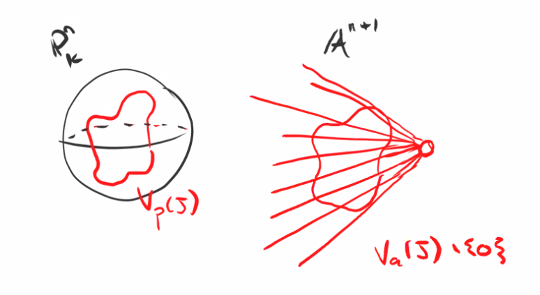

Image

By the affine Nullstellensatz,
$$\begin{align*} V_a(J) = \left\{{0}\right\} \iff \sqrt{J} = I_0 .\end{align*}$$

Thus $I_p(V_p(J)) = \left\langle{f ~{\text{s.t.}}~\text{homogeneous vanishing on }V_a(J)}\right\rangle$. Using the fact that $V_a(J)$ is a cone, its ideal is homogeneous and thus generated by homogeneous polynomials by part (b) of the previous proposition. Thus
$$\begin{align*} I_p(V_p(J)) = I_a(V_a(J)) = \sqrt J ,\end{align*}$$
where the last equality follows from the affine Nullstellensatz.

A better definition of a cone over $X\subset {\mathbb{P}}^n_{/k}$ is $\mkern 1.5mu\overline{\mkern-1.5mu\pi^{-1}(X)\mkern-1.5mu}\mkern 1.5mu \subset {\mathbb{A}}^{n+1}_{/k}$ where
$$\begin{align*} \pi: {\mathbb{A}}^{n+1}\setminus\left\{{0}\right\}&\to {\mathbb{P}}^n \\ {\left[ {x_0, \cdots, x_n} \right]} &\mapsto {\left[ {x_0: \cdots: x_n} \right]} .\end{align*}$$

Given $X\subset {\mathbb{P}}^n$ a projective variety, the **projective coordinate ring** of $X$ is given by
$$\begin{align*} S(X) \mathrel{\vcenter{:}}= k[x_1, \cdots, x_{n}] / I_p(X) .\end{align*}$$

This is a graded ring since $I_p(X)$ is homogeneous. This follows since the quotient of a graded ring by a homogeneous ideal yields a grading on the quotient.

We have relative versions of everything. Projective subvarieties of projective varieties are given by $Y\subset X\subset {\mathbb{P}}^n$ where $X$ is a projective variety. We have a topology on $X$ where the closed subsets are projective subvarieties.

Given $J\subset S(X)$, where $S(X)$ is the projective coordinate ring of $X$ and has a grading, we can take $V_p(J) \subset X$. Conversely, given a set $Y\subset S(X)$, we can take $I_p(Y) \subset S(X)$ those homogeneous elements vanishing on $Y$. Thus there is an order-reversing bijection
$$\begin{align*} \left\{{\substack{\text{Projective subvarieties } \\ Y\subset X}}\right\} \iff \left\{{\substack{\text{Homogeneous nonirrelevant radical ideals} \\ I \subset S(X)}}\right\} \end{align*}$$
and $S(X) = k[x_1, \cdots, x_{n}]/J \subset \mkern 1.5mu\overline{\mkern-1.5muI_0\mkern-1.5mu}\mkern 1.5mu$.

Every nontrivial homogeneous ideal $J$ contained in $I_0$. Why? Suppose $f\in J\setminus I_0$ and $f_0\neq 0$. Then $f_0\in J$ but $f_0\in k\subset k[x_1, \cdots, x_{n}]$, implying that $1\in J$ and thus $J = \left\langle{1}\right\rangle$.

It is sometimes useful to know that a projective variety is cut out by homogeneous polynomials all of *equal* degree, so $X = V (f_1, \cdots, f_m)$ with each $f_i$ homogeneous of degree $d_i$. Then there is some maximum degree $d$. We can write
$$\begin{align*} V(f_1) = V(x_0^k f_1, \cdots, x_n^k f_1 ) \qquad \forall k\geq 0 \\ X = \bigcap V(f_1) \cup V(x_i) .\end{align*}$$
This follows because $V$ of a product is a union of the vanishing loci, but $\bigcap V(x_i) = \emptyset$. The equality follows because for all points ${\left[ {x_0, \cdots, x_n} \right]} \in {\mathbb{P}}^n$, some $x_i$ is nonzero.